# Ortolan Bunting analysis

me

9 joulukuuta 2019

# 2. Peltosirkkuaineiston analyysi

Tutkimuskysymykset:

1. Peltosirkun häviämisnopeus kasvaa alueen avoimuuden vähentyessä ja eristyneisyyden kasvaessa
2. Peltosirkun häviämisnopeus kasvaa peltoviljelyn muuttuessa viljavaltaisesta nurmivaltaiseksi
3. Peltosirkun häviämisnopeus kasvaa viljelyn monimuotoisuuden vähentyessä
4. Peltosirkun häviämisnopeus kasvaa maiseman pienipiirteisten rakenteiden yksipuolistuessa

## 2.1 Aineiston tarkastelua

Luetaan aineisto sisään ja tarkistetaan, että luokkamuuttujat ovat oikein ja ettei joukossa ole NA:ta:

```r
data<-read.csv("OrtolanBunting.csv")

names(data)
```

```
##  [1] "id"      "year"    "agri5"   "area"    "ndvi"    "prec"    "temp"
##  [8] "terri"   "shan"    "snum"    "neo"     "shanG"   "open"    "cover"
## [15] "Abuild"  "Ariver"  "Astream" "Aroad"   "SSS"     "X"       "Y"
```

```r
str(data)
```

```
## 'data.frame':    1474 obs. of  21 variables:
##  $ id     : int  3 122 126 130 138 139 140 144 145 147 ...
##  $ year   : int  2000 2000 2000 2000 2000 2000 2000 2000 2000 2000 ...
##  $ agri5  : num  0.46 0.44 0.37 0.35 0.53 0.48 0.39 0.23 0.23 0.51 ...
##  $ area   : num  2.964 1.021 2.111 1.187 0.192 ...
##  $ ndvi   : num  0.441 0.441 0.441 0.441 0.441 0.441 0.441 0.441 0.441 0.441 ...
##  $ prec   : num  0.775 0.784 0.918 0.918 0.849 0.849 0.772 0.651 0.889 0.849 ...
##  $ temp   : num  17.3 17.5 17.4 17.4 17.5 ...
##  $ terri  : int  20 6 12 3 0 3 11 0 5 0 ...
##  $ shan   : num  2.33 1.4 2.18 1.83 1.68 ...
##  $ snum   : int  20 9 12 14 7 8 17 7 18 9 ...
##  $ neo    : num  0.0228 0 0.0628 0.1136 0.058 ...
##  $ shanG  : num  1.083 0.553 0.959 1.276 0.807 ...
##  $ open   : num  0.577 0.806 0.74 0.784 0.799 ...
##  $ cover  : num  0.419 0.176 0.26 0.215 0.201 ...
##  $ Abuild : num  0.626 1.783 -0.516 -0.344 -1.303 ...
##  $ Ariver : num  0.325 -0.547 -0.547 -0.547 2.242 ...
##  $ Astream: num  -0.545 -0.427 -0.274 -0.212 -1.029 ...
##  $ Aroad  : num  -0.0484 0.7353 -0.735 -0.9739 -0.9917 ...
##  $ SSS    : num  0.358 1.545 -2.072 -2.078 -1.082 ...
##  $ X      : num  422221 426751 371664 366068 425435 ...
##  $ Y      : num  6725615 6725480 6702677 6700163 6728051 ...
```

```r
summary(data)
```

```
##        id             year          agri5             area
##  Min.   :  1.0   Min.   :2000   Min.   :0.0400   Min.   :0.1673
##  1st Qu.: 67.0   1st Qu.:2005   1st Qu.:0.2725   1st Qu.:0.3125
##  Median :145.0   Median :2011   Median :0.3800   Median :0.6009
##  Mean   :142.3   Mean   :2011   Mean   :0.3784   Mean   :0.7988
##  3rd Qu.:219.0   3rd Qu.:2016   3rd Qu.:0.4800   3rd Qu.:0.9628
##  Max.   :279.0   Max.   :2018   Max.   :0.7700   Max.   :2.9829
##       ndvi             prec            temp           terri
##  Min.   :0.4150   Min.   :0.624   Min.   :11.24   Min.   : 0.000
##  1st Qu.:0.4170   1st Qu.:1.718   1st Qu.:13.53   1st Qu.: 0.000
##  Median :0.4300   Median :2.017   Median :14.22   Median : 1.000
##  Mean   :0.4307   Mean   :2.052   Mean   :14.37   Mean   : 3.005
##  3rd Qu.:0.4410   3rd Qu.:2.374   3rd Qu.:15.29   3rd Qu.: 4.000
##  Max.   :0.4580   Max.   :4.091   Max.   :17.83   Max.   :26.000
##       shan            snum            neo              shanG
##  Min.   :0.000   Min.   : 0.00   Min.   :0.00000   Min.   :0.0000
##  1st Qu.:1.233   1st Qu.: 6.00   1st Qu.:0.00000   1st Qu.:0.6464
##  Median :1.565   Median : 8.00   Median :0.00000   Median :0.8396
##  Mean   :1.527   Mean   : 9.18   Mean   :0.07017   Mean   :0.8317
##  3rd Qu.:1.874   3rd Qu.:12.00   3rd Qu.:0.09912   3rd Qu.:1.0594
##  Max.   :2.622   Max.   :28.00   Max.   :1.00000   Max.   :1.7875
##       open            cover            Abuild             Ariver
##  Min.   :0.0000   Min.   :0.0000   Min.   :-1.30335   Min.   :-0.54721
##  1st Qu.:0.5157   1st Qu.:0.1569   1st Qu.:-0.55697   1st Qu.:-0.54721
##  Median :0.6841   Median :0.2916   Median :-0.18656   Median :-0.54721
##  Mean   :0.6455   Mean   :0.3331   Mean   : 0.05258   Mean   :-0.08783
##  3rd Qu.:0.8271   3rd Qu.:0.4571   3rd Qu.: 0.45827   3rd Qu.:-0.05496
##  Max.   :1.0000   Max.   :1.0000   Max.   : 6.00376   Max.   : 4.93424
##     Astream             Aroad               SSS                 X
##  Min.   :-1.30406   Min.   :-2.85623   Min.   :-5.15489   Min.   :219788
##  1st Qu.:-0.61455   1st Qu.:-0.60932   1st Qu.:-1.32601   1st Qu.:300620
##  Median :-0.20224   Median :-0.12256   Median :-0.42820   Median :387254
##  Mean   :-0.07488   Mean   : 0.01713   Mean   :-0.09301   Mean   :367533
##  3rd Qu.: 0.36247   3rd Qu.: 0.62188   3rd Qu.: 1.01260   3rd Qu.:423478
##  Max.   : 5.07757   Max.   : 4.43533   Max.   : 8.75789   Max.   :678915
##        Y
##  Min.   :6659254
##  1st Qu.:6712307
##  Median :6725480
##  Mean   :6760542
##  3rd Qu.:6769346
##  Max.   :7193444
```

```r
#tarkasta kaikkien luokkien muoto
data$id<-as.factor(data$id)
#vuodelle oma faktori-muuttuja
data$fyear<-as.factor(data$year)
```

### 2.1.1 Poikkeavia havaintoja

Tarkastellaan havaintoja yksitellen, onko mukana virheitä tai poikkeavia havaintoja:

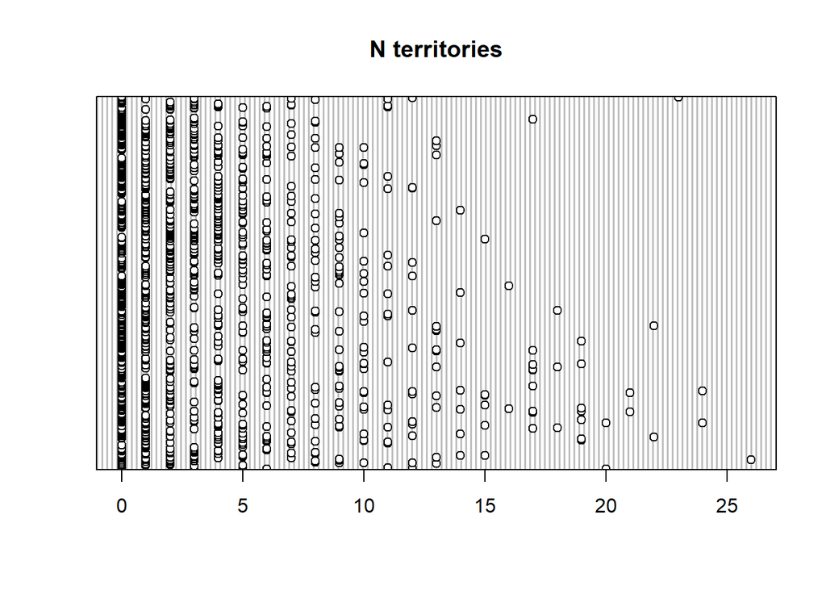

```r
#outliers
dotchart(data$terri, main= "N territories")
```

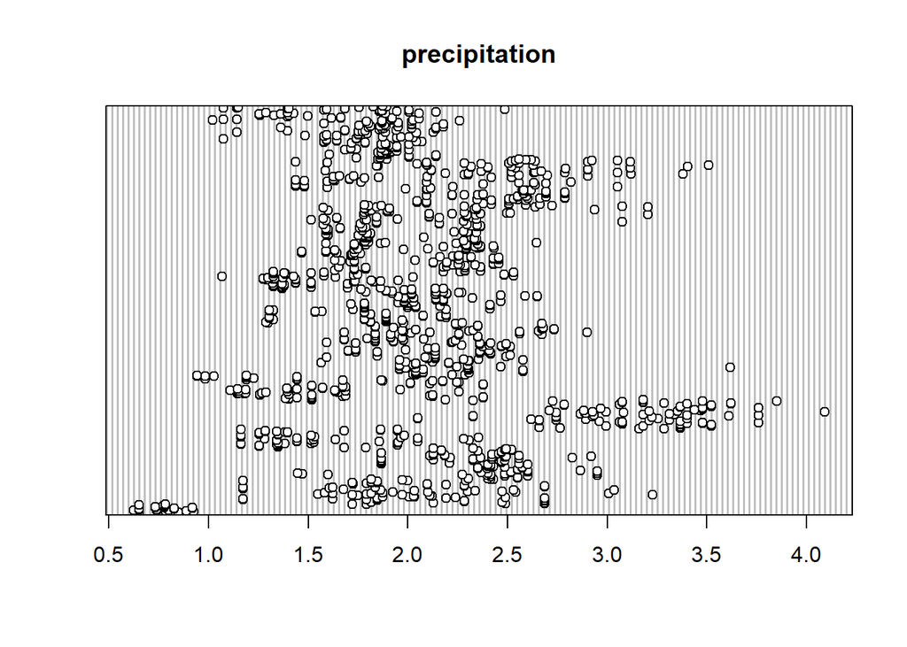

```r
dotchart(data$prec, main= "precipitation")
```

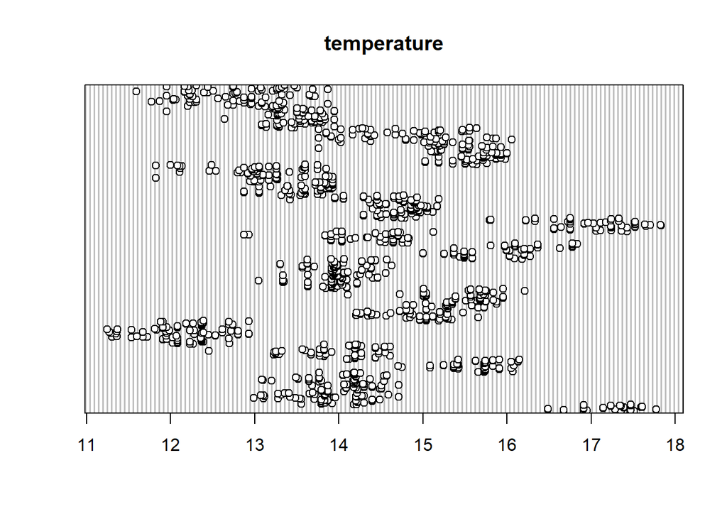

```r
dotchart(data$temp, main= "temperature")
```

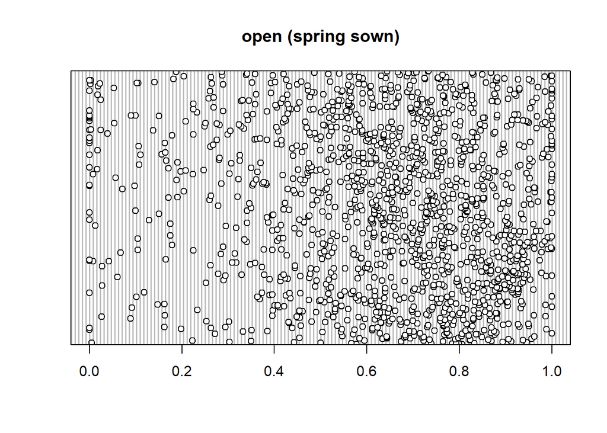

```r
dotchart(data$open, main= "open (spring sown)")
```

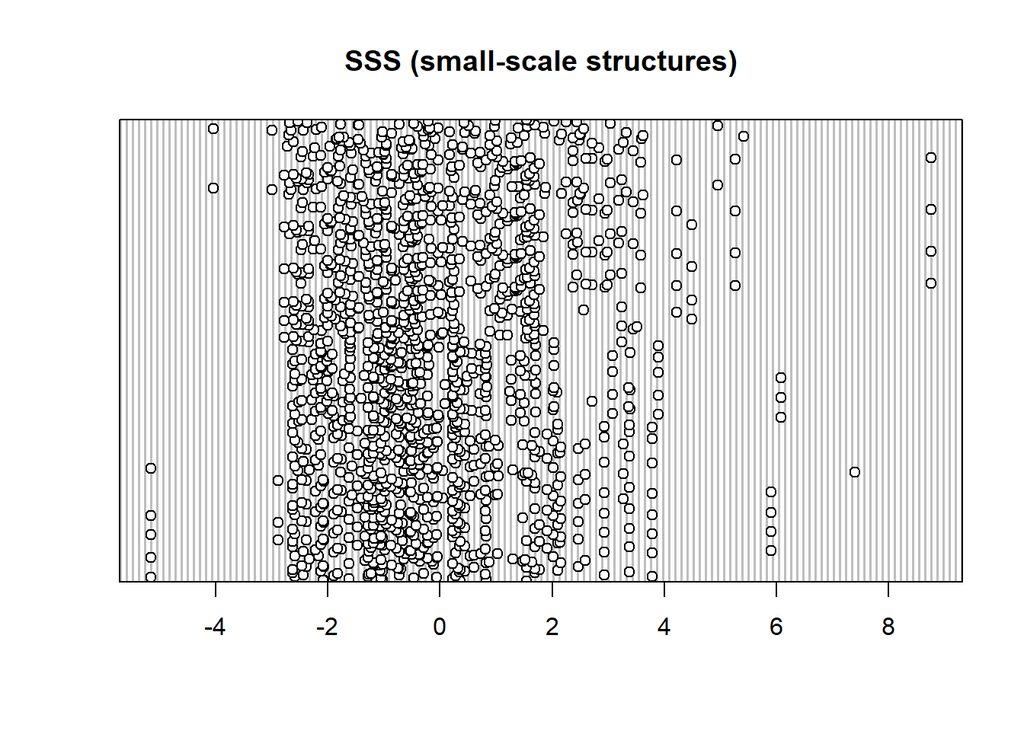

```r
dotchart(data$SSS, main= "SSS (small-scale structures)")
```

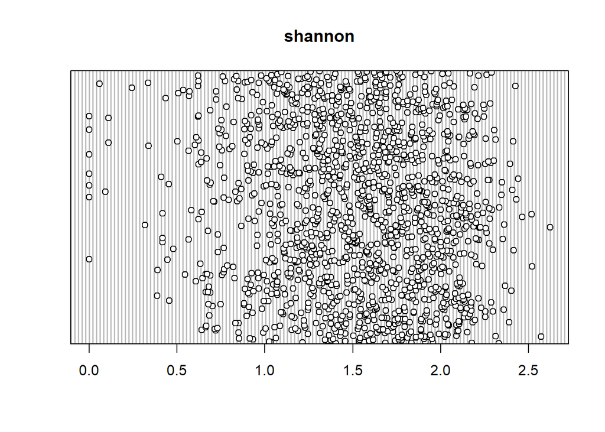

```r
dotchart(data$shan, main= "shannon")
```

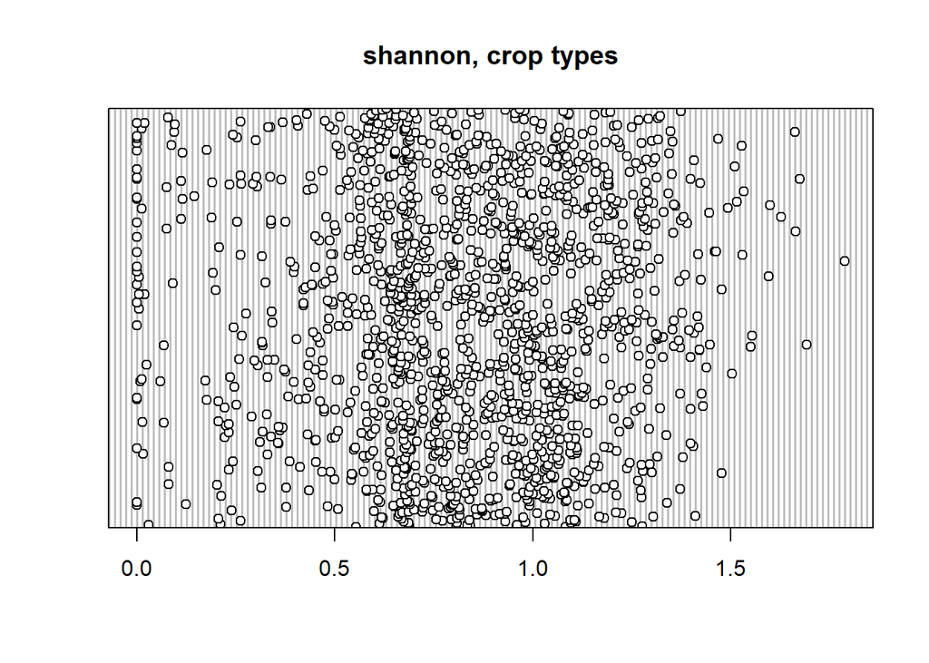

```r
dotchart(data$shanG, main= "shannon, crop types")
```

Kuinka monta reviiriä per osapopulaatio?

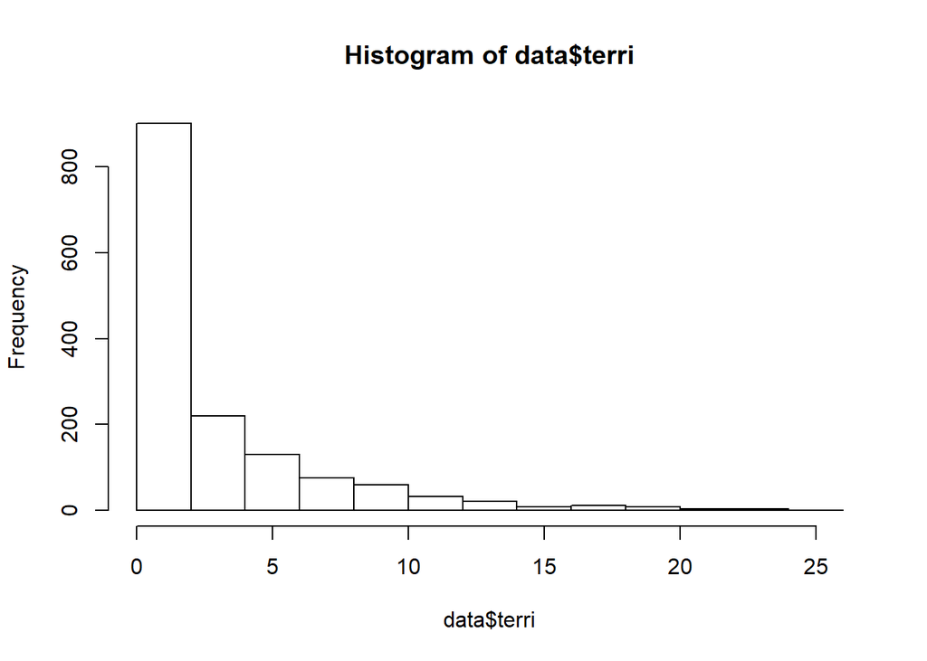

```r
hist(data$terri)
```

```r
table(data$terri)
```

```
##
##   0   1   2   3   4   5   6   7   8   9  10  11  12  13  14  15  16  17
## 540 213 147 116 103  72  58  43  32  34  25  19  14  14   7   6   2   9
##  18  19  20  21  22  23  24  26
##   3   7   2   2   2   1   2   1
```

Aineistossa on muutama “MEGA”osapopulaatio. Suurimmaksi osaksi osapopulaatiot ovat tyhjiä tai niillä on muutama reviiri.

Kuinka monta käyntikertaa per osapopulaatio?

```r
sort(table(data$id))
```

```
##
## 160 161 162 225 227 274  89 106 111 134 135 136 141 165 167 169 180 201
##   1   1   1   1   1   1   2   2   2   2   2   2   2   2   2   2   2   2
## 203 204 205 206 207 208 209 210 211 212 213 214 215 216 217 218 219 220
##   2   2   2   2   2   2   2   2   2   2   2   2   2   2   2   2   2   2
## 221 222 223 226 228 229 230 239 268  23  26  44  79  83  84  85  90  91
##   2   2   2   2   2   2   2   2   2   3   3   3   3   3   3   3   3   3
##  92  94  95  96  97  98  99 100 101 102 103 104 107 108 109 110 113 114
##   3   3   3   3   3   3   3   3   3   3   3   3   3   3   3   3   3   3
## 117 123 124 125 137 142 150 164 166 168 179 184 185 189 190 224 231 232
##   3   3   3   3   3   3   3   3   3   3   3   3   3   3   3   3   3   3
## 259 261 264 267 269 270 272 275 276 278  24  31  35  46  47  48  49  50
##   3   3   3   3   3   3   3   3   3   3   4   4   4   4   4   4   4   4
##  51  53  54  55  56  57  58  59  60  61  62  63  64  65  66  67  68  69
##   4   4   4   4   4   4   4   4   4   4   4   4   4   4   4   4   4   4
```

[output cut: 18 more lines]

Muutamalla osapopulaatiolla on käyty vain kerran.

### 2.1.2 Riippuvuussuhteita

Tarkastellaan muuttujia suhteessa toisiinsa:

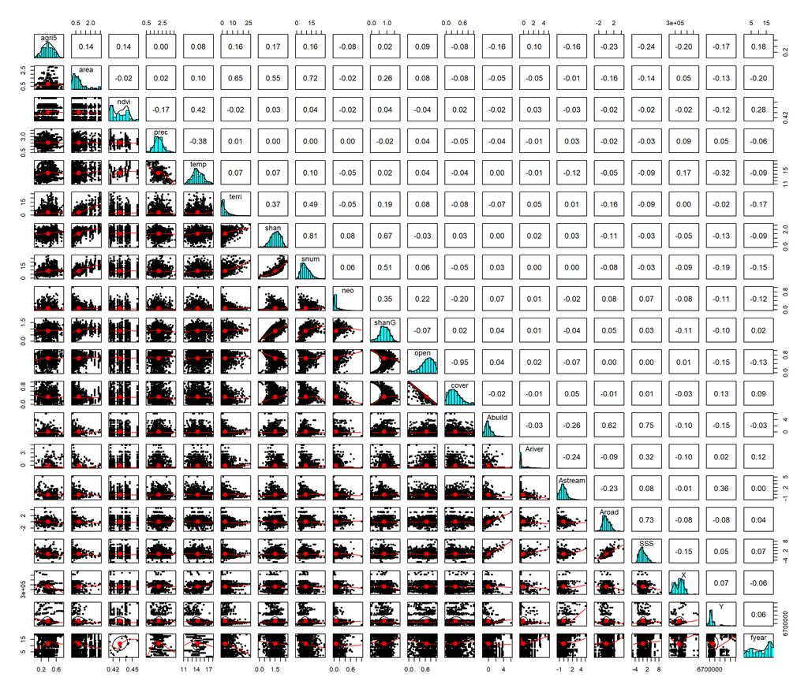

```r
#relationships
pairs.panels(data[,c(3:22)])
```

Reviirien lukumäärällä (terri) ja Shannon-Wienerin indeksillä (shan ja shanG) sekä lajien lukumäärällä (snum) on suht vahva korrelaatio. Myös maatalousmaiseman osuus (agri5) ja pienrakenteiden tiheys (SSS) nousevat esille. Huomaa, että teiden ja rakennusten suhde reviirien määrään on negatiivinen, kun taas jokien ja purojen on positiivinen.

Keväällä kylvettävien kasvien osuus (open) ja keväällä pidemmällä oraalla olevien kasvien (cover) osuudet ovat toistensa vastakohdat.

### 2.1.3 Lisää plottailua

Katsotaan reviirien määrän kehitystä kullakin osapopulaatiolla:

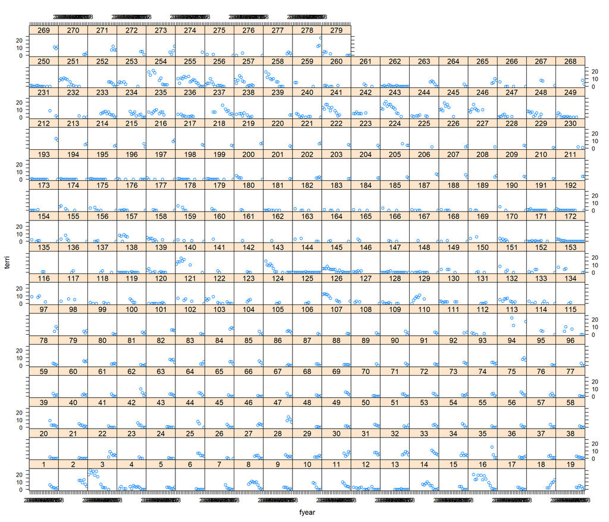

```r
#plottailua
xyplot(terri~fyear|id, data=data)
```

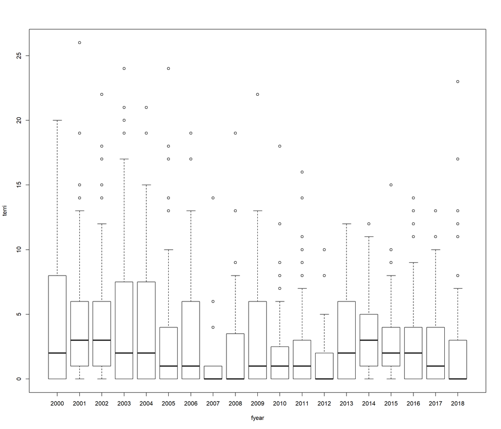

```r
boxplot(terri~fyear, data=data)
```

Trendi näyttäisi yleisesti olevan laskeva.

## 2.2 Mallit

Peruspiirteittäin suunniteltiin mallit näin:

M1 = year

M2 = year + kov

M3 = year + kov + weather x year

M4 = year + kov + pelto x year

M5 = year + kov + weather x year + pelto x year

Kov(ariaatit) tarkoittaa SSS, agri5 ja koordinaatteja. (“pakolliset kovariaatit”)  
Weather tarkoittaa sadantaa ja lämpötilaa.  
Pelto tarkoittaa shannon-indeksiä ja avoimen maan osuutta (open).

### 2.2.1 Nested/crossed, hierarchical ja muita ajatuksia

```r
#Aksun esimerkit (näissä mukana NDVI):
#m1=glmmTMB(N ~Year + (1|fYear) + (1|Site), family=nbinom2, data=Embhor)
#m2=glmmTMB(N ~SSS + Landscape + X + Y + X*Y + Year + (1|fYear) + (1|Site), family=nbinom2, data=Embhor)
#m3=glmmTMB(N ~SSS + Landscape + X + Y + X*Y + Year*Temp + Year*Rain + Year*NDVI + (1|fYear) + (1|Site), family=nbinom2, data=Embhor)
#m4=glmmTMB(N ~SSS + Landscape + X + Y + X*Y + Year*Cropdiv + Year*Plough + (1|fYear) + (1|Site), family=nbinom2, data=Embhor)
#m5=glmmTMB(N ~SSS + Landscape + X + Y + X*Y + Year*Temp + Year*Rain + Year*NDVI + Year*Cropdiv + Year*Plough + (1|fYear) + (1|Site), family=nbinom2, data=Embhor)
```

Mikään malleista ei aluksi toiminut, koska aineisto oli skaalaamaton. Alla kuitenkin asioita, joita tuli pohdittua ongelmaa selvittäessä:

Muuttuja ‘id’ eli jokaisen osapopulaaation yksilöivä tunniste on random-muuttuja koska se saattaa sisältää jotain informaatiota, jota fixed-muuttujat eivät sisällä koska koko populaatio ei ole täydellisesti edustettuna otoksessa.

Määritelmiä siitä, milloin effect on fixed tai random: “Effects are fixed if they are interesting in themselves or random if there is interest in the underlying population. When a sample exhausts the population, the corresponding variable is fixed; when the sample is a small (i.e., negligible) part of the population the corresponding variable is random”.

Mutta entäpä vuosi?

Random-efektinä vuosi huomioisi vuosien välisen ajallisen riippuvuuden. Osapopulaatiolla, jolla on monta lauluryhmää yhtenä vuonna, on suuremmalla todennäköisyydellä monta lauluryhmää myös seuraavana vuonna.  
Fixed-efektinä se selittäisi lauluryhmien määrässä tapahtuvaa vaihtelua suoraan. Vuodet ovat erilaisia (esim. tapahtumat Afrikassa vaihtelevat) ja jokin asia, jota emme ole tajunneet mitata voi selittyäkin vuodella.

Muuttuja sekä fixed että random-tekijänä?

Lue aiheesta [täältä](https://www.theanalysisfactor.com/mixed-models-predictor-both-fixed-random/). Voiko vuosi siis olla fixed effect vain silloin kun se on interaktiossa jonkun toisen muuttujan kanssa?

Nested or crossed?

Relatively few mixed effect modeling packages can handle crossed random effects, i.e. those where one level of a random effect can appear in conjunction with more than one level of another effect. (This definition is confusing, and I would happily accept a better one.) A classic example is crossed temporal and spatial effects. If there is random variation among temporal blocks (e.g. years) ‘’and’‘random variation among spatial blocks (e.g. sites),’‘and’‘if there is a consistent year effect across sites and’‘vice versa’’, then the random effects should be treated as crossed.

Selkeä vastaus lötyy [täältä](https://stats.stackexchange.com/questions/228800/crossed-vs-nested-random-effects-how-do-they-differ-and-how-are-they-specified).

Random-muuttujan havaintojen määrä?

Joillain osapopulaatioilla on käyty vain kerran, joillain taas täydet 19 kertaa. Jos osapopulaatio on random-tekijä täytyy siitä olla havaintoja useampia. Muuten ei pysty arvioimaan ryhmän sisäistä vaihtelua? Katso kysymys [aiheesta](https://stats.stackexchange.com/questions/242821/how-will-random-effects-with-only-1-observation-affect-a-generalized-linear-mixe). Vastaus on kai, että ei haittaa, kunhan vaihtelun saa arvioitua muista osapopulaatioista, joista on useampia havaintoja.

Muuttujien skaalaaminen?

Vuoden keskittäminen? Vuosi 2000 olisi baseline ja siitä eteenpäin vuosi 1,2,3 jne. Tai Cyear = year-mean(year). Uusi muuttuja.

### 2.2.2 GLMM-mallit

#### Ei pinta-alaa mukana

Skaalataan aineisto ja kokeillaan glmm-malleja. Sovitetaan viisi hypoteesiemme mukaista glmm-mallia ja tulostetaan niiden AICc-taulukko:

```r
dataS=data %>%mutate_at(c(2:3,5:7,9:14,20:21), funs(c(scale(.))))
M1=glmmTMB(terri ~ year + (1|fyear)+ (1|id), family=nbinom2, data=dataS, REML=FALSE)

M2=glmmTMB(terri ~ SSS + agri5 + X*Y + year + (1|fyear) + (1|id), family=nbinom2, data=dataS, REML=FALSE)

M3=glmmTMB(terri ~ SSS + agri5 + X*Y + year*temp + year*prec  + (1|fyear)  + (1|id), family=nbinom2, data=dataS, REML=FALSE)

M4=glmmTMB(terri ~ SSS + agri5 + X*Y + year*shan + year*open + (1|fyear) + (1|id), family=nbinom2, data=dataS, REML=FALSE)

M5=glmmTMB(terri ~ SSS + agri5 + X*Y + year*temp + year*prec + year*shan + year*open + (1|fyear) + (1|id), family=nbinom2, data=dataS, REML=FALSE)

output1<-model.sel(M1,M2,M3,M4,M5)

# AICc Table
output1
```

```
## Model selection table
##    cnd((Int)) dsp((Int)) cnd(yer) cnd(ag5) cnd(SSS)     cnd(X) cnd(Y)
## M4     0.5950          +  -0.7477   0.4866  0.02605 -0.0010750 0.2141
## M5     0.5879          +  -0.7721   0.4886  0.02475 -0.0063980 0.2320
## M2     0.5849          +  -0.7963   0.5152  0.03027 -0.0002277 0.2024
## M3     0.5778          +  -0.8188   0.5156  0.02904 -0.0045380 0.2185
## M1     0.6560          +  -0.7941
##    cnd(X:Y)  cnd(prc) cnd(tmp) cnd(prc:yer) cnd(tmp:yer)  cnd(opn)
## M4  0.01514                                               0.001192
## M5  0.01741 -0.001346  0.04447     -0.03578      0.06297 -0.001747
## M2  0.01382
## M3  0.01545 -0.003928  0.04060     -0.03611      0.05366
## M1
##    cnd(shn) cnd(opn:yer) cnd(shn:yer) df    logLik   AICc delta weight
## M4   0.1485     -0.05685     -0.03168 14 -2736.203 5500.7  0.00  0.679
## M5   0.1493     -0.05622     -0.03302 18 -2733.028 5502.5  1.83  0.272
## M2                                    10 -2743.196 5506.5  5.85  0.036
## M3                                    14 -2740.203 5508.7  8.00  0.012
## M1                                     5 -2763.107 5536.3 35.56  0.000
## Models ranked by AICc(x)
## Random terms (all models):
## 'cond(1 | fyear)', 'cond(1 | id)'
```

Taulukon mukaan mallit M4 ja M5 ovat parhaimpia, 1.83 AICc yksikön erolla toisistaan. Mallit eroavat toisistaan vuoden ja lämpötilan sekä sadannan interaktioiden suhteen. M4 on yksinkertaisempi eli ilman ilmastomuuttujia.

Tehdään model averaging M4 ja M5 malleilla:

```r
output2=model.sel(M4,M5)

#tehdään model averaging
summary(model.avg(output2, revised.var = TRUE))
```

```
##
## Call:
## model.avg(object = output2, revised.var = TRUE)
##
## Component model call:
## glmmTMB(formula = terri ~ <2 unique rhs>, data = dataS, family =
##      nbinom2, REML = FALSE, ziformula = ~0, dispformula = ~1)
##
## Component models:
##                                  df   logLik    AICc delta weight
## 1/2/3/4/5/6/7/8/9/10             14 -2736.20 5500.69  0.00   0.71
## 1/2/3/4/5/6/7/8/9/10/11/12/13/14 18 -2733.03 5502.53  1.83   0.29
##
## Term codes:
##     cond(agri5)      cond(open)      cond(shan)       cond(SSS)
##               1               2               3               4
##         cond(X)         cond(Y)      cond(year) cond(open:year)
##               5               6               7               8
## cond(shan:year)       cond(X:Y)      cond(prec)      cond(temp)
##               9              10              11              12
## cond(prec:year) cond(temp:year)
##              13              14
##
## Model-averaged coefficients:
## (full average)
##                   Estimate Std. Error Adjusted SE z value Pr(>|z|)
## cond((Int))      0.5929762  0.0964141   0.0964940   6.145  < 2e-16 ***
## cond(SSS)        0.0256773  0.0450031   0.0450405   0.570 0.568614
## cond(agri5)      0.4871827  0.0898355   0.0899101   5.419    1e-07 ***
## cond(X)         -0.0025963  0.0835793   0.0836487   0.031 0.975239
## cond(Y)          0.2192469  0.0685765   0.0686327   3.194 0.001401 **
## cond(year)      -0.7546649  0.0649970   0.0650494  11.601  < 2e-16 ***
## cond(shan)       0.1487331  0.0439008   0.0439373   3.385 0.000712 ***
## cond(open)       0.0003518  0.0420322   0.0420671   0.008 0.993328
## cond(X:Y)        0.0157925  0.0622742   0.0623259   0.253 0.799970
## cond(shan:year) -0.0320625  0.0352030   0.0352322   0.910 0.362805
## cond(open:year) -0.0566689  0.0378469   0.0378783   1.496 0.134634
## cond(temp)       0.0127113  0.0315038   0.0315194   0.403 0.686737
## cond(prec)      -0.0003848  0.0177986   0.0178134   0.022 0.982766
## cond(temp:year)  0.0180001  0.0362825   0.0362941   0.496 0.619930
## cond(prec:year) -0.0102285  0.0226476   0.0226569   0.451 0.651665
##
## (conditional average)
##                   Estimate Std. Error Adjusted SE z value Pr(>|z|)
## cond((Int))      0.5929762  0.0964141   0.0964940   6.145  < 2e-16 ***
## cond(SSS)        0.0256773  0.0450031   0.0450405   0.570 0.568614
## cond(agri5)      0.4871827  0.0898355   0.0899101   5.419    1e-07 ***
## cond(X)         -0.0025963  0.0835793   0.0836487   0.031 0.975239
## cond(Y)          0.2192469  0.0685765   0.0686327   3.194 0.001401 **
## cond(year)      -0.7546649  0.0649970   0.0650494  11.601  < 2e-16 ***
## cond(shan)       0.1487331  0.0439008   0.0439373   3.385 0.000712 ***
## cond(open)       0.0003518  0.0420322   0.0420671   0.008 0.993328
## cond(X:Y)        0.0157925  0.0622742   0.0623259   0.253 0.799970
## cond(shan:year) -0.0320625  0.0352030   0.0352322   0.910 0.362805
## cond(open:year) -0.0566689  0.0378469   0.0378783   1.496 0.134634
## cond(temp)       0.0444711  0.0453858   0.0454236   0.979 0.327565
## cond(prec)      -0.0013462  0.0332717   0.0332994   0.040 0.967752
## cond(temp:year)  0.0629739  0.0421114   0.0421464   1.494 0.135131
## cond(prec:year) -0.0357846  0.0296637   0.0296884   1.205 0.228073
## ---
## Signif. codes:  0 '***' 0.001 '**' 0.01 '*' 0.05 '.' 0.1 ' ' 1
```

Taulukon tulkinta on hieman epäselvää mulle. Taulukkohan vihjaa ettei interaktiot olisi merkittäviä, mutta mehän halutaan tutkia nimenomaan interaktioita koska ne linkittyvät asioihin, jotka kertovat reviirien lukumäärän vuosittaisesta muutoksesta. Muuttujien tutkiminen ilman interaktiota vuoden kanssa ei ole tässä tapauksessa mielekästä, koska se selittäisi ennemminkin asioita, jotka vaikuttavat reviirien absoluuttiseen lukumäärään, ei muutokseen. Ko,kö?

```r
summary(M4)
```

```
##  Family: nbinom2  ( log )
## Formula:
## terri ~ SSS + agri5 + X * Y + year * shan + year * open + (1 |
##     fyear) + (1 | id)
## Data: dataS
##
##      AIC      BIC   logLik deviance df.resid
##   5500.4   5574.5  -2736.2   5472.4     1460
##
## Random effects:
##
## Conditional model:
##  Groups Name        Variance Std.Dev.
##  fyear  (Intercept) 0.02449  0.1565
##  id     (Intercept) 1.75908  1.3263
## Number of obs: 1474, groups:  fyear, 19; id, 277
##
## Overdispersion parameter for nbinom2 family ():   10
##
## Conditional model:
##              Estimate Std. Error z value Pr(>|z|)
## (Intercept)  0.595006   0.096773   6.148 7.82e-10 ***
## SSS          0.026047   0.044977   0.579 0.562513
## agri5        0.486596   0.089794   5.419 5.99e-08 ***
## X           -0.001075   0.083300  -0.013 0.989705
## Y            0.214144   0.067726   3.162 0.001567 **
## year        -0.747702   0.064733 -11.551  < 2e-16 ***
## shan         0.148492   0.043937   3.380 0.000726 ***
## open         0.001192   0.041983   0.028 0.977352
## X:Y          0.015143   0.062197   0.243 0.807636
## year:shan   -0.031681   0.035202  -0.900 0.368136
## year:open   -0.056850   0.037813  -1.503 0.132722
## ---
## Signif. codes:  0 '***' 0.001 '**' 0.01 '*' 0.05 '.' 0.1 ' ' 1
```

Mä jatkaisin tästä karsimalla mallista pois ei-merkitsevät interaktiot ja muuttujat. Mulla on tässä prosessissa vähän logiikka hakusessa.

Mallin validointi:

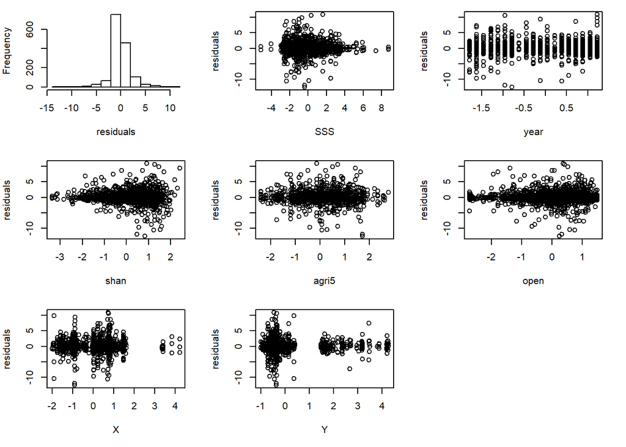

```r
#malli uudelleen, ML-asetuksella
M4=glmmTMB(terri ~ SSS + agri5 + X*Y + year*shan + year*open + (1|fyear) + (1|id), family=nbinom2, data=dataS)

op<-par(mfrow=c(3,3),mar=c(5,4,1,2))
#plot(M4,add.smooth = F,which =1)
E<-resid(M4)
hist(E, xlab = "residuals",main = "")
plot(dataS$SSS,E,xlab = "SSS",ylab="residuals")
plot(dataS$year,E,xlab = "year",ylab="residuals")
plot(dataS$shan,E,xlab = "shan",ylab="residuals")
plot(dataS$agri5,E,xlab = "agri5",ylab="residuals")
plot(dataS$open,E,xlab = "open",ylab="residuals")
plot(dataS$X,E,xlab = "X",ylab="residuals")
plot(dataS$Y,E,xlab = "Y",ylab="residuals")
par(op)
```

Hmm..

#### Pinta-ala offsettina:

```r
M1=glmmTMB(terri ~ year + offset(log(area)) + (1|fyear)+ (1|id), family=nbinom2, data=dataS, REML=FALSE)

M2=glmmTMB(terri ~ SSS + agri5 + X*Y + year + offset(log(area))+ (1|fyear) + (1|id), family=nbinom2, data=dataS,REML=FALSE)

M3=glmmTMB(terri ~ SSS + agri5 + X*Y + year*temp + year*prec  + offset(log(area))+ (1|fyear)  + (1|id), family=nbinom2, data=dataS,REML=FALSE)

M4=glmmTMB(terri ~ SSS + agri5 + X*Y + year*shan + year*open + offset(log(area))+ (1|fyear) + (1|id), family=nbinom2, data=dataS,REML=FALSE)

M5=glmmTMB(terri ~ SSS + agri5 + X*Y + year*temp + year*prec + year*shan + year*open + offset(log(area))+ (1|fyear) + (1|id), family=nbinom2, data=dataS,REML=FALSE)

output1<-model.sel(M1,M2,M3,M4,M5)
output1
```

```
## Model selection table
##    cnd((Int)) dsp((Int)) cnd(yer) cnd(off(log(are))) cnd(ag5) cnd(SSS)
## M4      1.208          +  -0.5938                  +   0.4087  0.05618
## M2      1.216          +  -0.6620                  +   0.4330  0.06127
## M5      1.202          +  -0.6166                  +   0.4115  0.05574
## M3      1.210          +  -0.6843                  +   0.4349  0.06092
## M1      1.298          +  -0.6756                  +
##      cnd(X) cnd(Y) cnd(X:Y)  cnd(prc) cnd(tmp) cnd(prc:yer) cnd(tmp:yer)
## M4 -0.01314 0.2322  0.03253
## M2 -0.01426 0.2314  0.04357
## M5 -0.01687 0.2510  0.03364 -0.008410  0.04629     -0.03502      0.05602
## M3 -0.01723 0.2483  0.04429 -0.009083  0.04318     -0.03613      0.04683
## M1
##    cnd(opn) cnd(shn) cnd(opn:yer) cnd(shn:yer) df    logLik   AICc delta
## M4 -0.01000  0.05607     -0.04244     -0.07581 14 -2680.025 5388.3  0.00
## M2                                             10 -2684.193 5388.5  0.20
## M5 -0.01197  0.05756     -0.04386     -0.07694 18 -2677.171 5390.8  2.47
## M3                                             14 -2681.536 5391.4  3.02
## M1                                              5 -2712.916 5435.9 47.54
##    weight
## M4  0.414
## M2  0.375
## M5  0.120
## M3  0.091
## M1  0.000
## Models ranked by AICc(x)
## Random terms (all models):
## 'cond(1 | fyear)', 'cond(1 | id)'
```

```r
output2=model.sel(M4,M2)

#tehdään model averaging
summary(model.avg(output2, revised.var = TRUE))
```

```
##
## Call:
## model.avg(object = output2, revised.var = TRUE)
##
## Component model call:
## glmmTMB(formula = terri ~ <2 unique rhs>, data = dataS, family =
##      nbinom2, REML = FALSE, ziformula = ~0, dispformula = ~1)
##
## Component models:
##                         df   logLik    AICc delta weight
## 1/2/3/4/5/6/7/8/9/10/11 14 -2680.03 5388.34   0.0   0.52
## 1/4/5/6/7/10/11         10 -2684.19 5388.54   0.2   0.48
##
## Term codes:
##             cond(agri5)              cond(open)              cond(shan)
##                       1                       2                       3
##               cond(SSS)                 cond(X)                 cond(Y)
##                       4                       5                       6
##              cond(year)         cond(open:year)         cond(shan:year)
##                       7                       8                       9
##               cond(X:Y) cond(offset(log(area)))
##                      10                      11
##
## Model-averaged coefficients:
## (full average)
##                  Estimate Std. Error Adjusted SE z value Pr(>|z|)
## cond((Int))      1.212045   0.077383    0.077447  15.650  < 2e-16 ***
## cond(SSS)        0.058603   0.035853    0.035883   1.633    0.102
## cond(agri5)      0.420251   0.071714    0.071771   5.855  < 2e-16 ***
## cond(X)         -0.013672   0.065296    0.065351   0.209    0.834
## cond(Y)          0.231813   0.052800    0.052844   4.387 1.15e-05 ***
## cond(year)      -0.626212   0.069395    0.069439   9.018  < 2e-16 ***
## cond(shan)       0.029420   0.040355    0.040372   0.729    0.466
## cond(open)      -0.005247   0.029229    0.029252   0.179    0.858
## cond(X:Y)        0.037774   0.049010    0.049050   0.770    0.441
## cond(shan:year) -0.039780   0.044946    0.044957   0.885    0.376
## cond(open:year) -0.022270   0.033481    0.033498   0.665    0.506
##
## (conditional average)
##                 Estimate Std. Error Adjusted SE z value Pr(>|z|)
## cond((Int))      1.21205    0.07738     0.07745  15.650  < 2e-16 ***
## cond(SSS)        0.05860    0.03585     0.03588   1.633   0.1024
## cond(agri5)      0.42025    0.07171     0.07177   5.855  < 2e-16 ***
## cond(X)         -0.01367    0.06530     0.06535   0.209   0.8343
## cond(Y)          0.23181    0.05280     0.05284   4.387 1.15e-05 ***
## cond(year)      -0.62621    0.06939     0.06944   9.018  < 2e-16 ***
## cond(shan)       0.05607    0.04012     0.04015   1.396   0.1626
## cond(open)      -0.01000    0.03976     0.03979   0.251   0.8016
## cond(X:Y)        0.03777    0.04901     0.04905   0.770   0.4412
## cond(shan:year) -0.07581    0.03344     0.03347   2.265   0.0235 *
## cond(open:year) -0.04244    0.03578     0.03581   1.185   0.2359
## ---
## Signif. codes:  0 '***' 0.001 '**' 0.01 '*' 0.05 '.' 0.1 ' ' 1
```

M2 olisi näistä vaihtoehdoista yksinkertaisin.

Mallin validointi:

```r
#malli uudelleen, ML-asetuksella
M2=glmmTMB(terri ~ SSS + agri5 + X*Y + year + offset(log(area))+ (1|fyear) + (1|id), family=nbinom2, data=dataS)
summary(M2)
```

```
##  Family: nbinom2  ( log )
## Formula:
## terri ~ SSS + agri5 + X * Y + year + offset(log(area)) + (1 |
##     fyear) + (1 | id)
## Data: dataS
##
##      AIC      BIC   logLik deviance df.resid
##   5388.4   5441.3  -2684.2   5368.4     1464
##
## Random effects:
##
## Conditional model:
##  Groups Name        Variance Std.Dev.
##  fyear  (Intercept) 0.01779  0.1334
##  id     (Intercept) 1.02943  1.0146
## Number of obs: 1474, groups:  fyear, 19; id, 277
##
## Overdispersion parameter for nbinom2 family (): 10.6
##
## Conditional model:
##             Estimate Std. Error z value Pr(>|z|)
## (Intercept)  1.21606    0.07776  15.639  < 2e-16 ***
## SSS          0.06127    0.03639   1.684   0.0922 .
## agri5        0.43295    0.07140   6.064 1.33e-09 ***
## X           -0.01426    0.06661  -0.214   0.8305
## Y            0.23140    0.05371   4.308 1.65e-05 ***
## year        -0.66204    0.05603 -11.816  < 2e-16 ***
## X:Y          0.04357    0.04938   0.882   0.3776
## ---
## Signif. codes:  0 '***' 0.001 '**' 0.01 '*' 0.05 '.' 0.1 ' ' 1
```

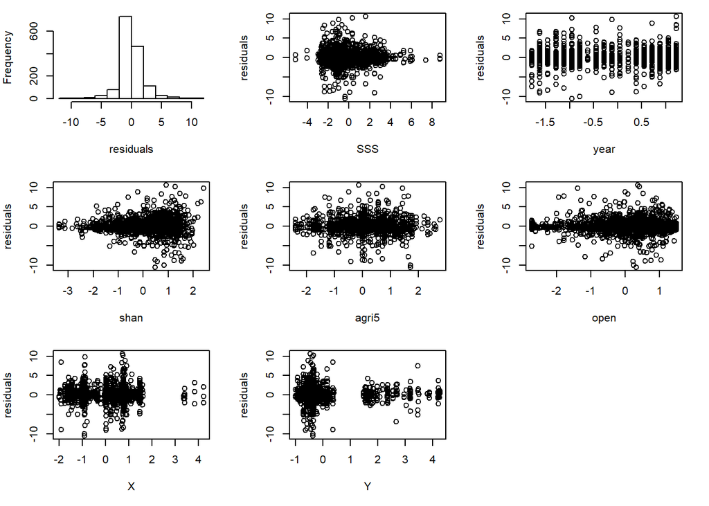

```r
op<-par(mfrow=c(3,3),mar=c(5,4,1,2))
E<-resid(M2)
hist(E, xlab = "residuals",main = "")
plot(dataS$SSS,E,xlab = "SSS",ylab="residuals")
plot(dataS$year,E,xlab = "year",ylab="residuals")
plot(dataS$shan,E,xlab = "shan",ylab="residuals")
plot(dataS$agri5,E,xlab = "agri5",ylab="residuals")
plot(dataS$open,E,xlab = "open",ylab="residuals")
plot(dataS$X,E,xlab = "X",ylab="residuals")
plot(dataS$Y,E,xlab = "Y",ylab="residuals")
par(op)
```

Vaikuttaisi siltä, että ainoita merkitseviä tekijöitä ovat vuosi, agri5 ja Y-koordinaatti.

Residuaalien tulkinta on mulla vähän hakusessa.

#### Pinta-ala kovariaattina:

Samat mallit mutta niin, että pinta-ala onkin oma kovariaattinsa.

```r
M1=glmmTMB(terri ~ year + log(area) + (1|fyear)+ (1|id), family=nbinom2, data=dataS, REML=FALSE)

M2=glmmTMB(terri ~ SSS + agri5 + X*Y + year + log(area)+ (1|fyear) + (1|id), family=nbinom2, data=dataS, REML=FALSE)

M3=glmmTMB(terri ~ SSS + agri5 + X*Y + year*temp + year*prec  + log(area)+ (1|fyear)  + (1|id), family=nbinom2, data=dataS, REML=FALSE)

M4=glmmTMB(terri ~ SSS + agri5 + X*Y + year*shan + year*open + log(area)+ (1|fyear) + (1|id), family=nbinom2, data=dataS, REML=FALSE)

M5=glmmTMB(terri ~ SSS + agri5 + X*Y + year*temp + year*prec + year*shan + year*open + log(area) + (1|fyear) + (1|id), family=nbinom2, data=dataS, REML=FALSE)

output1<-model.sel(M1,M2,M3,M4,M5)
output1
```

```
## Model selection table
##    cnd((Int)) dsp((Int)) cnd(log(are)) cnd(yer) cnd(ag5) cnd(SSS)   cnd(X)
## M2      1.349          +         1.234  -0.6513   0.4250  0.07060 -0.01701
## M4      1.325          +         1.207  -0.5884   0.4068  0.06477 -0.01517
## M3      1.344          +         1.235  -0.6738   0.4272  0.07029 -0.01973
## M5      1.318          +         1.206  -0.6112   0.4095  0.06430 -0.01849
## M1      1.424          +         1.209  -0.6675
##    cnd(Y) cnd(X:Y)  cnd(prc) cnd(tmp) cnd(prc:yer) cnd(tmp:yer) cnd(opn)
## M2 0.2418  0.05158
## M4 0.2382  0.03713                                              -0.01863
## M3 0.2588  0.05233 -0.010480  0.04251     -0.03538      0.04818
## M5 0.2568  0.03816 -0.009783  0.04485     -0.03431      0.05623 -0.02045
## M1
##    cnd(shn) cnd(opn:yer) cnd(shn:yer) df    logLik   AICc delta weight
## M2                                    11 -2681.306 5384.8  0.00  0.524
## M4  0.02653     -0.03601     -0.07648 15 -2677.880 5386.1  1.30  0.274
## M3                                    15 -2678.657 5387.6  2.85  0.126
## M5  0.02849     -0.03759     -0.07764 19 -2675.053 5388.6  3.84  0.077
## M1                                     6 -2710.962 5434.0 49.19  0.000
## Models ranked by AICc(x)
## Random terms (all models):
## 'cond(1 | fyear)', 'cond(1 | id)'
```

```r
output2=model.sel(M4,M2)

#tehdään model averaging
summary(model.avg(output2, revised.var = TRUE))
```

```
##
## Call:
## model.avg(object = output2, revised.var = TRUE)
##
## Component model call:
## glmmTMB(formula = terri ~ <2 unique rhs>, data = dataS, family =
##      nbinom2, REML = FALSE, ziformula = ~0, dispformula = ~1)
##
## Component models:
##                         df   logLik    AICc delta weight
## 1/2/5/6/7/8/11          11 -2681.31 5384.79   0.0   0.66
## 1/2/3/4/5/6/7/8/9/10/11 15 -2677.88 5386.09   1.3   0.34
##
## Term codes:
##     cond(agri5) cond(log(area))      cond(open)      cond(shan)
##               1               2               3               4
##       cond(SSS)         cond(X)         cond(Y)      cond(year)
##               5               6               7               8
## cond(open:year) cond(shan:year)       cond(X:Y)
##               9              10              11
##
## Model-averaged coefficients:
## (full average)
##                  Estimate Std. Error Adjusted SE z value Pr(>|z|)
## cond((Int))      1.340620   0.095588    0.095666  14.014  < 2e-16 ***
## cond(SSS)        0.068600   0.036251    0.036281   1.891   0.0586 .
## cond(agri5)      0.418720   0.071193    0.071251   5.877  < 2e-16 ***
## cond(X)         -0.016379   0.065551    0.065605   0.250   0.8028
## cond(Y)          0.240543   0.053057    0.053101   4.530  5.9e-06 ***
## cond(year)      -0.629730   0.066265    0.066308   9.497  < 2e-16 ***
## cond(log(area))  1.224640   0.099363    0.099444  12.315  < 2e-16 ***
## cond(X:Y)        0.046615   0.049340    0.049380   0.944   0.3452
## cond(shan)       0.009109   0.027881    0.027899   0.326   0.7440
## cond(open)      -0.006396   0.025042    0.025061   0.255   0.7985
## cond(shan:year) -0.026259   0.041255    0.041263   0.636   0.5245
## cond(open:year) -0.012363   0.027123    0.027137   0.456   0.6487
##
## (conditional average)
##                 Estimate Std. Error Adjusted SE z value Pr(>|z|)
## cond((Int))      1.34062    0.09559     0.09567  14.014  < 2e-16 ***
## cond(SSS)        0.06860    0.03625     0.03628   1.891   0.0586 .
## cond(agri5)      0.41872    0.07119     0.07125   5.877  < 2e-16 ***
## cond(X)         -0.01638    0.06555     0.06560   0.250   0.8028
## cond(Y)          0.24054    0.05306     0.05310   4.530  5.9e-06 ***
## cond(year)      -0.62973    0.06626     0.06631   9.497  < 2e-16 ***
## cond(log(area))  1.22464    0.09936     0.09944  12.315  < 2e-16 ***
## cond(X:Y)        0.04662    0.04934     0.04938   0.944   0.3452
## cond(shan)       0.02653    0.04245     0.04248   0.625   0.5323
## cond(open)      -0.01863    0.03998     0.04002   0.466   0.6415
## cond(shan:year) -0.07648    0.03340     0.03343   2.288   0.0222 *
## cond(open:year) -0.03601    0.03593     0.03596   1.001   0.3167
## ---
## Signif. codes:  0 '***' 0.001 '**' 0.01 '*' 0.05 '.' 0.1 ' ' 1
```

M2 näyttäisi paremmalta valinnalta.

Mallin validointi:

```r
#malli uudelleen, ML-asetuksella
M2=glmmTMB(terri ~ SSS + agri5 + X*Y + year + log(area)+ (1|fyear) + (1|id), family=nbinom2, data=dataS)
summary(M2)
```

```
##  Family: nbinom2  ( log )
## Formula:
## terri ~ SSS + agri5 + X * Y + year + log(area) + (1 | fyear) +
##     (1 | id)
## Data: dataS
##
##      AIC      BIC   logLik deviance df.resid
##   5384.6   5442.9  -2681.3   5362.6     1463
##
## Random effects:
##
## Conditional model:
##  Groups Name        Variance Std.Dev.
##  fyear  (Intercept) 0.01789  0.1337
##  id     (Intercept) 1.00997  1.0050
## Number of obs: 1474, groups:  fyear, 19; id, 277
##
## Overdispersion parameter for nbinom2 family (): 10.5
##
## Conditional model:
##             Estimate Std. Error z value Pr(>|z|)
## (Intercept)  1.34902    0.09489  14.216  < 2e-16 ***
## SSS          0.07060    0.03651   1.934   0.0531 .
## agri5        0.42498    0.07109   5.978 2.26e-09 ***
## X           -0.01701    0.06632  -0.256   0.7976
## Y            0.24176    0.05359   4.511 6.45e-06 ***
## year        -0.65132    0.05647 -11.534  < 2e-16 ***
## log(area)    1.23392    0.09761  12.641  < 2e-16 ***
## X:Y          0.05158    0.04926   1.047   0.2951
## ---
## Signif. codes:  0 '***' 0.001 '**' 0.01 '*' 0.05 '.' 0.1 ' ' 1
```

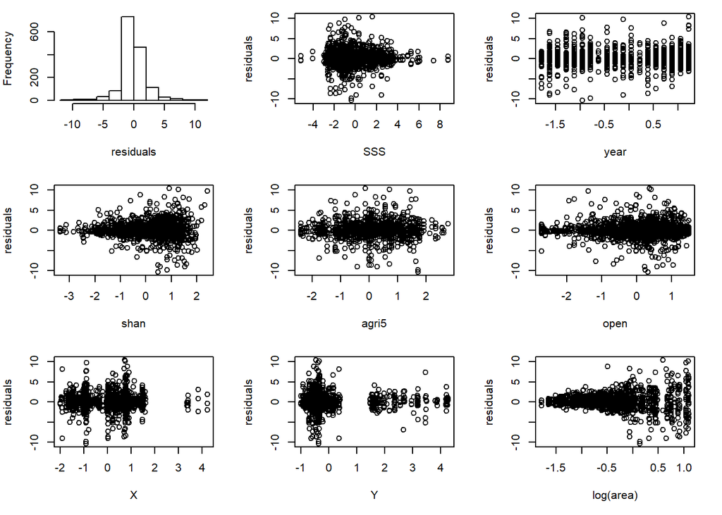

```r
op<-par(mfrow=c(3,3),mar=c(5,4,1,2))
E<-resid(M2)
hist(E, xlab = "residuals",main = "")
plot(dataS$SSS,E,xlab = "SSS",ylab="residuals")
plot(dataS$year,E,xlab = "year",ylab="residuals")
plot(dataS$shan,E,xlab = "shan",ylab="residuals")
plot(dataS$agri5,E,xlab = "agri5",ylab="residuals")
plot(dataS$open,E,xlab = "open",ylab="residuals")
plot(dataS$X,E,xlab = "X",ylab="residuals")
plot(dataS$Y,E,xlab = "Y",ylab="residuals")
plot(log(dataS$area),E,xlab = "log(area)",ylab="residuals")
```

```r
par(op)
```

Pinta-alan laittaminen kovariaatiksi ei näytä muuttuvan tuloksia pääpiirteissään. Log(area) on merkitsevä.

#### SSS muuttuja pilkottuna

Testaan huvikseen mallia, jossa SSS onkin korvattu osatekijöillään.

```r
M1=glmmTMB(terri ~ year + offset(log(area)) + (1|fyear)+ (1|id), family=nbinom2, data=dataS, REML=FALSE)

M2=glmmTMB(terri ~ Abuild + Astream + Aroad + Ariver + agri5 + X*Y + year + offset(log(area))+ (1|fyear) + (1|id), family=nbinom2, data=dataS, REML=FALSE)

M3=glmmTMB(terri ~ Abuild + Astream + Aroad + Ariver + agri5 + X*Y + year*temp + year*prec  + offset(log(area))+ (1|fyear)  + (1|id), family=nbinom2, data=dataS, REML=FALSE)

M4=glmmTMB(terri ~ Abuild + Astream + Aroad + Ariver + agri5 + X*Y + year*shan + year*open + offset(log(area))+ (1|fyear) + (1|id), family=nbinom2, data=dataS, REML=FALSE)

M5=glmmTMB(terri ~ Abuild + Astream + Aroad + Ariver + agri5 + X*Y + year*temp + year*prec + year*shan + year*open + offset(log(area)) + (1|fyear) + (1|id), family=nbinom2, data=dataS, REML=FALSE)

output1<-model.sel(M1,M2,M3,M4,M5)
output1
```

```
## Model selection table
##    cnd((Int)) dsp((Int)) cnd(yer) cnd(off(log(are))) cnd(Abl) cnd(ag5)
## M4      1.216          +  -0.5951                  +  -0.1365   0.3637
## M2      1.224          +  -0.6616                  +  -0.1437   0.3880
## M5      1.210          +  -0.6182                  +  -0.1414   0.3661
## M3      1.218          +  -0.6843                  +  -0.1484   0.3898
## M1      1.298          +  -0.6756                  +
##    cnd(Arv) cnd(Ard) cnd(Ast)   cnd(X) cnd(Y) cnd(X:Y) cnd(prc) cnd(tmp)
## M4   0.2423   0.1239  0.03641 -0.01289 0.1988  0.04783
## M2   0.2530   0.1354  0.05224 -0.01409 0.1930  0.05931
## M5   0.2448   0.1257  0.03545 -0.01655 0.2178  0.04925 -0.01014  0.04674
## M3   0.2553   0.1374  0.05175 -0.01692 0.2098  0.06032 -0.01068  0.04330
## M1
##    cnd(prc:yer) cnd(tmp:yer) cnd(opn) cnd(shn) cnd(opn:yer) cnd(shn:yer)
## M4                           -0.01026  0.05806     -0.04444     -0.07385
## M2
## M5     -0.03455      0.06040 -0.01214  0.05973     -0.04616     -0.07526
## M3     -0.03575      0.05046
## M1
##    df    logLik   AICc delta weight
## M4 17 -2673.756 5381.9  0.00  0.400
## M2 13 -2677.937 5382.1  0.19  0.363
## M5 21 -2670.724 5384.1  2.15  0.136
## M3 17 -2675.134 5384.7  2.76  0.101
## M1  5 -2712.916 5435.9 53.94  0.000
## Models ranked by AICc(x)
## Random terms (all models):
## 'cond(1 | fyear)', 'cond(1 | id)'
```

```r
output2=model.sel(M4,M2)

#tehdään model averaging
summary(model.avg(output2, revised.var = TRUE))
```

```
##
## Call:
## model.avg(object = output2, revised.var = TRUE)
##
## Component model call:
## glmmTMB(formula = terri ~ <2 unique rhs>, data = dataS, family =
##      nbinom2, REML = FALSE, ziformula = ~0, dispformula = ~1)
##
## Component models:
##                                  df   logLik    AICc delta weight
## 1/2/3/4/5/6/7/8/9/10/11/12/13/14 17 -2673.76 5381.93  0.00   0.52
## 1/2/3/4/5/8/9/10/13/14           13 -2677.94 5382.12  0.19   0.48
##
## Term codes:
##            cond(Abuild)             cond(agri5)            cond(Ariver)
##                       1                       2                       3
##             cond(Aroad)           cond(Astream)              cond(open)
##                       4                       5                       6
##              cond(shan)                 cond(X)                 cond(Y)
##                       7                       8                       9
##              cond(year)         cond(open:year)         cond(shan:year)
##                      10                      11                      12
##               cond(X:Y) cond(offset(log(area)))
##                      13                      14
##
## Model-averaged coefficients:
## (full average)
##                  Estimate Std. Error Adjusted SE z value Pr(>|z|)
## cond((Int))      1.219969   0.076390    0.076454  15.957  < 2e-16 ***
## cond(Abuild)    -0.139947   0.088095    0.088168   1.587 0.112450
## cond(Astream)    0.043951   0.081091    0.081158   0.542 0.588132
## cond(Aroad)      0.129346   0.084304    0.084374   1.533 0.125273
## cond(Ariver)     0.247407   0.069171    0.069228   3.574 0.000352 ***
## cond(agri5)      0.375283   0.071999    0.072057   5.208    2e-07 ***
## cond(X)         -0.013462   0.064007    0.064060   0.210 0.833558
## cond(Y)          0.196067   0.057001    0.057048   3.437 0.000588 ***
## cond(year)      -0.626765   0.068868    0.068912   9.095  < 2e-16 ***
## cond(shan)       0.030408   0.041032    0.041049   0.741 0.458823
## cond(open)      -0.005372   0.029118    0.029141   0.184 0.853736
## cond(X:Y)        0.053298   0.048502    0.048542   1.098 0.272211
## cond(shan:year) -0.038678   0.044088    0.044099   0.877 0.380439
## cond(open:year) -0.023278   0.034099    0.034116   0.682 0.495038
##
## (conditional average)
##                 Estimate Std. Error Adjusted SE z value Pr(>|z|)
## cond((Int))      1.21997    0.07639     0.07645  15.957  < 2e-16 ***
## cond(Abuild)    -0.13995    0.08810     0.08817   1.587 0.112450
## cond(Astream)    0.04395    0.08109     0.08116   0.542 0.588132
## cond(Aroad)      0.12935    0.08430     0.08437   1.533 0.125273
## cond(Ariver)     0.24741    0.06917     0.06923   3.574 0.000352 ***
## cond(agri5)      0.37528    0.07200     0.07206   5.208    2e-07 ***
## cond(X)         -0.01346    0.06401     0.06406   0.210 0.833558
## cond(Y)          0.19607    0.05700     0.05705   3.437 0.000588 ***
## cond(year)      -0.62676    0.06887     0.06891   9.095  < 2e-16 ***
## cond(shan)       0.05806    0.04011     0.04015   1.446 0.148131
## cond(open)      -0.01026    0.03961     0.03964   0.259 0.795815
## cond(X:Y)        0.05330    0.04850     0.04854   1.098 0.272211
## cond(shan:year) -0.07385    0.03337     0.03340   2.211 0.027038 *
## cond(open:year) -0.04444    0.03577     0.03580   1.242 0.214398
## ---
## Signif. codes:  0 '***' 0.001 '**' 0.01 '*' 0.05 '.' 0.1 ' ' 1
```

Sama homma. M2 näyttäisi paremmalta valinnalta.

Mallin validointi:

```r
#malli uudelleen, ML-asetuksella
M2=glmmTMB(terri ~ Abuild + Astream + Aroad + Ariver + agri5 + X*Y + year + offset(log(area))+ (1|fyear) + (1|id), family=nbinom2, data=dataS, REML=FALSE)
summary(M2)
```

```
##  Family: nbinom2  ( log )
## Formula:
## terri ~ Abuild + Astream + Aroad + Ariver + agri5 + X * Y + year +
##     offset(log(area)) + (1 | fyear) + (1 | id)
## Data: dataS
##
##      AIC      BIC   logLik deviance df.resid
##   5381.9   5450.7  -2677.9   5355.9     1461
##
## Random effects:
##
## Conditional model:
##  Groups Name        Variance Std.Dev.
##  fyear  (Intercept) 0.01808  0.1345
##  id     (Intercept) 0.97797  0.9889
## Number of obs: 1474, groups:  fyear, 19; id, 277
##
## Overdispersion parameter for nbinom2 family (): 10.6
##
## Conditional model:
##             Estimate Std. Error z value Pr(>|z|)
## (Intercept)  1.22426    0.07667  15.968  < 2e-16 ***
## Abuild      -0.14374    0.08940  -1.608 0.107878
## Astream      0.05224    0.08209   0.636 0.524482
## Aroad        0.13537    0.08530   1.587 0.112514
## Ariver       0.25303    0.07013   3.608 0.000308 ***
## agri5        0.38799    0.07172   5.410 6.32e-08 ***
## X           -0.01409    0.06526  -0.216 0.829106
## Y            0.19301    0.05786   3.336 0.000851 ***
## year        -0.66163    0.05595 -11.826  < 2e-16 ***
## X:Y          0.05931    0.04883   1.215 0.224520
## ---
## Signif. codes:  0 '***' 0.001 '**' 0.01 '*' 0.05 '.' 0.1 ' ' 1
```

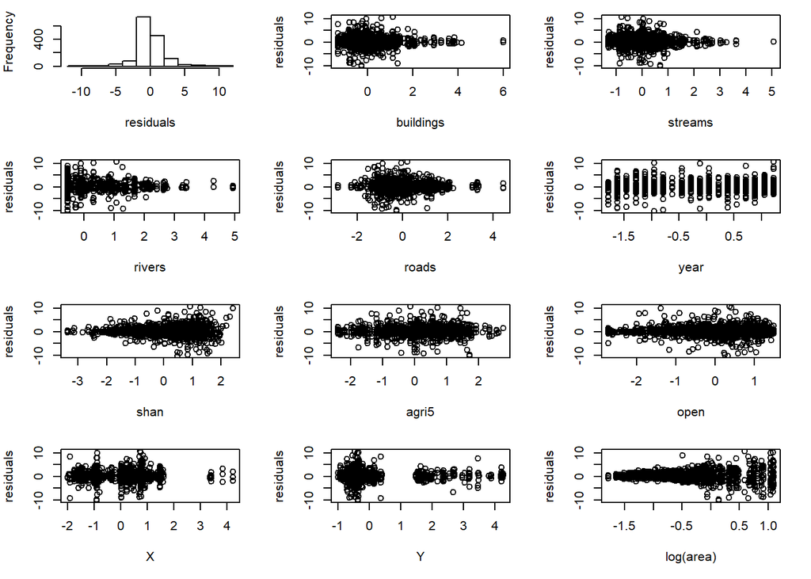

```r
op<-par(mfrow=c(4,3),mar=c(5,4,1,2))
E<-resid(M2)
hist(E, xlab = "residuals",main = "")
plot(dataS$Abuild,E,xlab = "buildings",ylab="residuals")
plot(dataS$Astream,E,xlab = "streams",ylab="residuals")
plot(dataS$Ariver,E,xlab = "rivers",ylab="residuals")
plot(dataS$Aroad,E,xlab = "roads",ylab="residuals")
plot(dataS$year,E,xlab = "year",ylab="residuals")
plot(dataS$shan,E,xlab = "shan",ylab="residuals")
plot(dataS$agri5,E,xlab = "agri5",ylab="residuals")
plot(dataS$open,E,xlab = "open",ylab="residuals")
plot(dataS$X,E,xlab = "X",ylab="residuals")
plot(dataS$Y,E,xlab = "Y",ylab="residuals")
plot(log(dataS$area),E,xlab = "log(area)",ylab="residuals")
```

```r
par(op)
```

### 2.2.3 GAM-malli, Tweedie

Päätettiin kokeilla mallinnusta niin, että selitettävänä muuttujana onkin reviirien tiheys. Näin osapopulaatioiden vaihteleva pinta-ala saadaan paremmin huomioitua. Osapopulaatiohan oli jo aikaisemminkin random-mmuuttujana, joten pinta-alan aiheuttama vaihtelu muuttujissa oli huomioitu jo jollain tasolla, mutta ei ehkä riittävästi.

SSS eli pienten rakenteiden lukumäärä tai pituudet on suhteutettu osapopulaation pinta-alaan. Mietin, tuleeko pinta-ala tässä tapauksessa huomioitua kahteen kertaan?

Tweedie-asiaa [täällä](https://stat.ethz.ch/R-manual/R-patched/library/mgcv/html/Tweedie.html) ja mgcv-paketista [täällä](https://people.maths.bris.ac.uk/~sw15190/mgcv/tampere/mgcv.pdf) ja [täällä](https://cran.r-project.org/web/packages/mgcv/mgcv.pdf). “Tweedie is an alternative to quasi when var(y) = φµp , 1 < p < 2, and a full distribution is required (for a non-negative real response).”

Luodaan uusi muuttuja ‘terriD’, joka on reviirien lkm jaettuna osapopulaation pinta-alalla (reviiriä/km2):

```r
#reviirien tiheys
dataS$terriD=dataS$terri/dataS$area
summary(dataS$terriD)
```

```
##    Min. 1st Qu.  Median    Mean 3rd Qu.    Max.
##   0.000   0.000   2.770   3.404   5.513  24.446
```

Plotataan aineisto uudelleen, kaksi kuvaajaa:

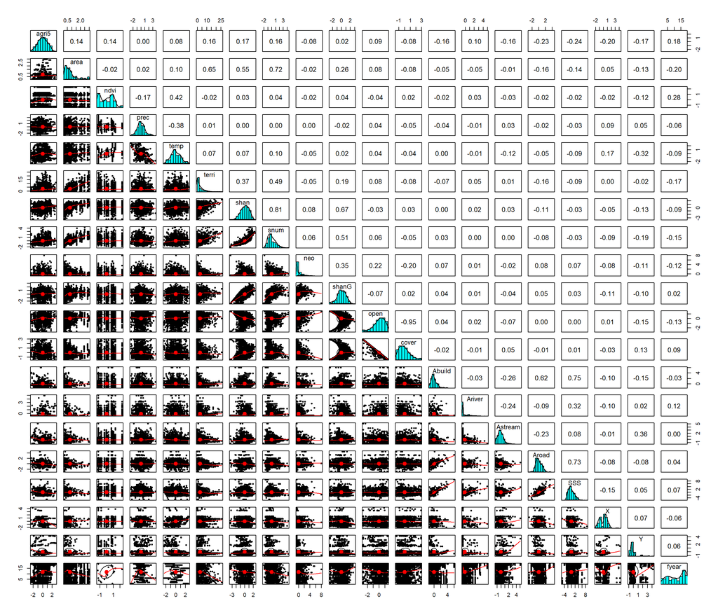

```r
#relationships
pairs.panels(dataS[,c(3:22)])
```

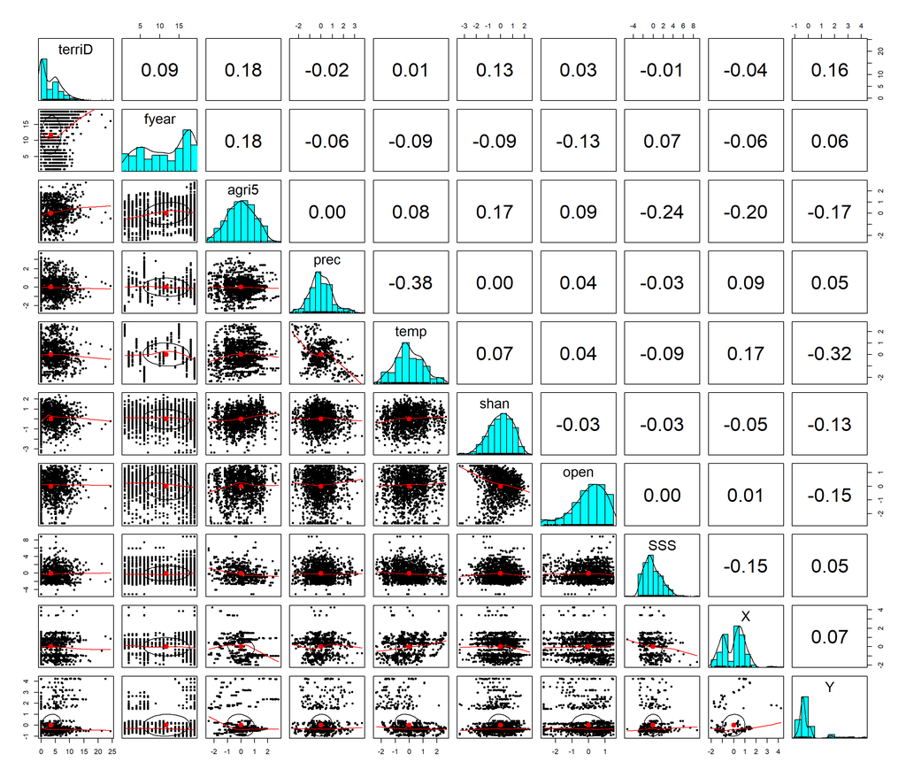

```r
pairs.panels(dataS[,c("terriD","fyear","agri5","prec","temp","shan","open","SSS","X","Y")])
```

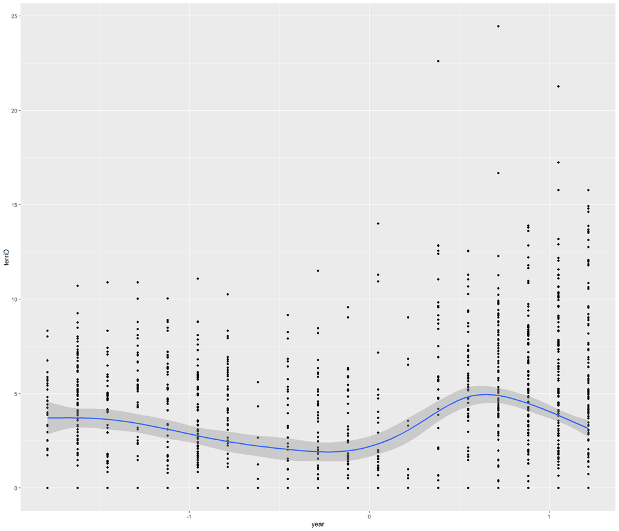

```r
ggplot(dataS, aes(x=year,y=terriD))+ geom_point() + geom_smooth()
```

Reviiritiheys mennyt alas, ylös ja alas.

Sadanta ja lämpötila negatiivisesti korreloituneita.

Mallien sovitus: HJÄLP! Vaikea löytää esimerkkejä. Tässä joitain: [esim1](https://gist.github.com/gavinsimpson/6d05af9186b9f9419cca5a4507af3aa0),

Muuttujan voi laittaa random-tekijäksi myös määrittämällä se smootherissa: s(…,bs=“re”) Lue [tämä](https://stat.ethz.ch/R-manual/R-devel/library/mgcv/html/random.effects.html) ja [tämä](https://stats.stackexchange.com/questions/197952/two-methods-of-adding-random-effects-to-a-gam-give-very-different-results-why-i). Näin voi käyttää gam-funktiota, jolloin family=tw (eikä Tweedie) eikä Tweedien p-arvoa tarvitse määrittää.

```r
G1=gam(terriD ~  year + s(fyear,bs="re") + s(id,bs="re"), data=dataS, family=tw, REML=FALSE)

G2=gam(terriD ~  year + agri5 + SSS + s(Y) + s(X) + s(fyear,bs="re") + s(id,bs="re"), data=dataS, family=tw, REML=FALSE)

G3=gam(terriD ~ agri5 + SSS + s(Y) + s(X) + year*temp + year*prec + s(fyear,bs="re") + s(id,bs="re"), data=dataS, family=tw, REML=FALSE)

G4=gam(terriD ~ agri5 + SSS + s(Y) + s(X) + year*shan + year*open + s(fyear,bs="re") + s(id,bs="re"), data=dataS, family=tw, REML=FALSE)

G5=gam(terriD ~ agri5 + SSS + s(Y) + s(X) + year*shan + year*open + year*temp + year*prec + s(fyear,bs="re") + s(id,bs="re"), data=dataS, family=tw, REML=FALSE)

AIC(G1,G2,G3,G4,G5)
```

```
##          df      AIC
## G1 237.4910 6052.945
## G2 221.4887 6002.881
## G3 224.2187 6005.786
## G4 217.0851 6014.904
## G5 219.8207 6017.515
```

G2 malli saa pienimmän AIC arvon.

Mallin validointia… Vaatisi vähän syventymistä aiheeseen..

```r
summary(G2)
```

```
##
## Family: Tweedie(p=1.15)
## Link function: log
##
## Formula:
## terriD ~ year + agri5 + SSS + s(Y) + s(X) + s(fyear, bs = "re") +
##     s(id, bs = "re")
##
## Parametric coefficients:
##             Estimate Std. Error t value Pr(>|t|)
## (Intercept)  1.08167    0.07847  13.784  < 2e-16 ***
## year        -0.42447    0.07076  -5.999 2.60e-09 ***
## agri5        0.30507    0.06192   4.927 9.46e-07 ***
## SSS          0.04866    0.02765   1.760   0.0786 .
## ---
## Signif. codes:  0 '***' 0.001 '**' 0.01 '*' 0.05 '.' 0.1 ' ' 1
##
## Approximate significance of smooth terms:
##              edf  Ref.df      F  p-value
## s(Y)       5.155   5.456 14.769 7.81e-15 ***
## s(X)       5.112   5.452  9.115 6.10e-09 ***
## s(fyear)  12.416  17.000  6.275 4.83e-14 ***
## s(id)    189.906 274.000  2.372  < 2e-16 ***
## ---
## Signif. codes:  0 '***' 0.001 '**' 0.01 '*' 0.05 '.' 0.1 ' ' 1
##
## R-sq.(adj) =  0.534   Deviance explained = 50.5%
## -REML = 3107.2  Scale est. = 2.256     n = 1474
```

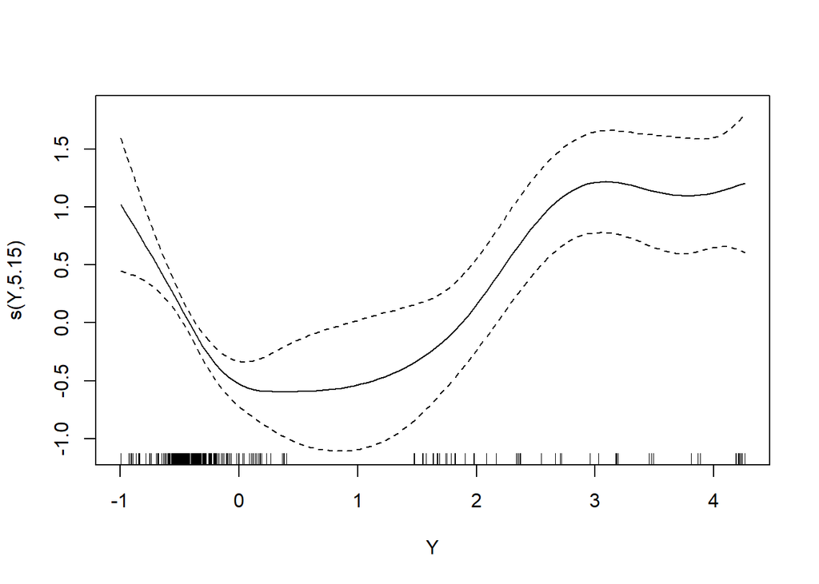

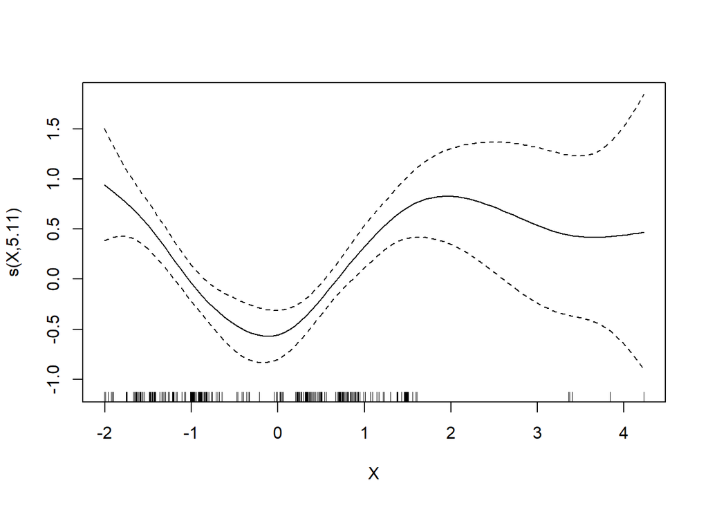

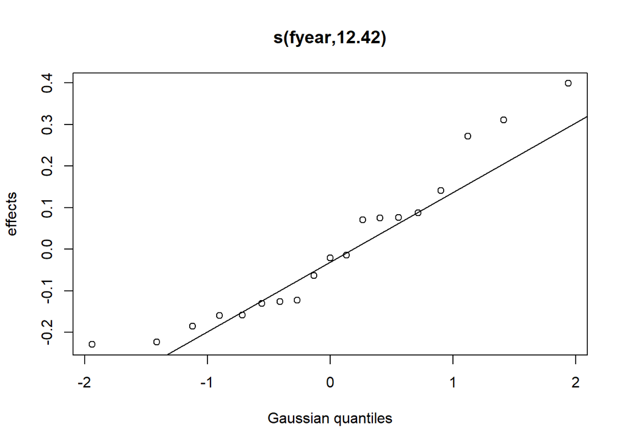

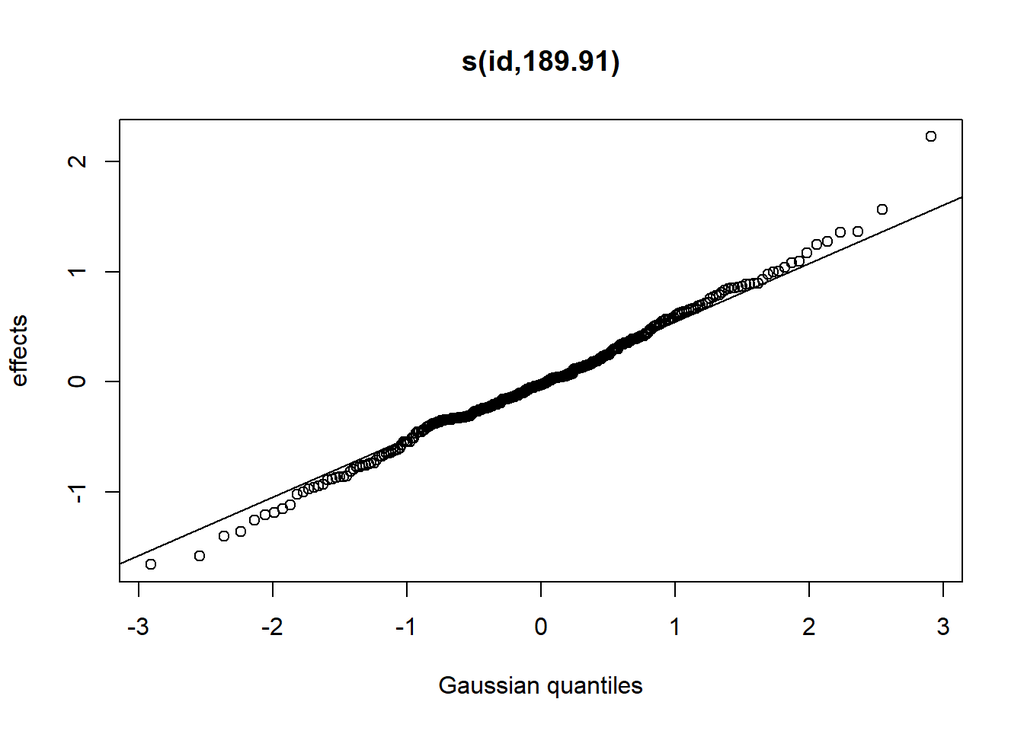

```r
plot(G2)
```

```r
G2$gam
```

GAM-mallien validointi ja visualisointi on vielä vähän hakusessa. Residuaalit pitäisi tässäkin tarkistaa.

### 2.2.4 GAM, NB, offset, (0 + vuosi|lauluryhmä)

Perus-GAM, jossa random-rakenne on smootherina.

Mutta [tässä](http://martijnwieling.nl/files/GAM-tutorial-Wieling.pdf) tutoriaalissa sanotaan ettei random slopen ja random interceptin välille ole mahdollista ohjelmoida gam-funktiolla korrelaatiota:

*4.7.2 Including a random slope* In similar fashion, we may include a by-speaker linear random slope (which would correspond to tilting the non-linear pattern) for the two-word-contrast (Word) as follows:

m4 <- bam(Pos ~ Word + s(Time, by=Word) + s(Speaker,bs=“re”) + s(Speaker,Word,bs=“re”), data=dat)

In the lmer specification this random slope would be represented by **(0+Word|Speaker)**. Unfortunately, in the GAM specification, it is not possible to model a correlation between random intercepts and random slopes (i.e. an lmer specification such as (1+Word|Speaker) is not possible). At present this is a drawback compared to linear mixed-effects regression, at least when linear random slopes are used.

Eli alla käyttämäni random-rakenne ei ole oikein, tai ainakaan just se mitä haetaan. Pitäisi kai käyttää GAMM-funktiota sit kuitenkin.

```r
M0 <- gam(terri ~ year + s(year,id, bs ="re"), offset=log(area), family = nb(), data= dataS, method = "ML")

M1 <- gam(terri ~ SSS + agri5*year + s(Y, bs ="cs") + s(X, bs ="cs") + s(year,id, bs="re"), offset=log(area), family = nb(),data= dataS, method = "ML")

M2 <- gam(terri ~ SSS + agri5*year + s(Y, bs ="cs") + s(X, bs ="cs") + year*temp + year*prec + s(year,id, bs="re"), offset=log(area), family = nb(), data= dataS, method = "ML")

M3 <- gam(terri ~ SSS + agri5*year + s(Y, bs ="cs") + s(X, bs ="cs") + year*shanG + year*open + s(year,id, bs="re"), offset=log(area), family = nb(), data= dataS, method = "ML")

M4 <- gam(terri ~ SSS + agri5*year + s(Y, bs ="cs") + s(X, bs ="cs") + year*temp + year*prec + year*shanG + year*open + s(year,id, bs="re"), offset=log(area), family = nb(), data= dataS, method = "ML")

AIC(M0,M1,M2,M3,M4)
```

```
##          df      AIC
## M0 148.2595 5636.071
## M1 184.4165 5293.912
## M2 194.2198 5260.391
## M3 185.1763 5303.468
## M4 200.5729 5274.076
```

M2 ja M4 ovat parhaimpia näistä. M2 on yksinkertaisempi.

```r
summary(M2)
```

```
##
## Family: Negative Binomial(5.303)
## Link function: log
##
## Formula:
## terri ~ SSS + agri5 * year + s(Y, bs = "cs") + s(X, bs = "cs") +
##     year * temp + year * prec + s(year, id, bs = "re")
##
## Parametric coefficients:
##             Estimate Std. Error z value Pr(>|z|)
## (Intercept)  0.87717    0.03548  24.721  < 2e-16 ***
## SSS          0.01780    0.02156   0.825  0.40919
## agri5        0.26021    0.05224   4.981 6.33e-07 ***
## year        -0.14772    0.05369  -2.751  0.00593 **
## temp         0.07981    0.02862   2.789  0.00529 **
## prec        -0.02697    0.02856  -0.945  0.34487
## agri5:year   0.09804    0.05151   1.903  0.05698 .
## year:temp    0.08549    0.02780   3.076  0.00210 **
## year:prec   -0.03725    0.02490  -1.496  0.13474
## ---
## Signif. codes:  0 '***' 0.001 '**' 0.01 '*' 0.05 '.' 0.1 ' ' 1
##
## Approximate significance of smooth terms:
##                edf Ref.df Chi.sq p-value
## s(Y)         5.736      9 1490.5  <2e-16 ***
## s(X)         5.231      9  689.9  <2e-16 ***
## s(year,id) 170.785    276  615.1  <2e-16 ***
## ---
## Signif. codes:  0 '***' 0.001 '**' 0.01 '*' 0.05 '.' 0.1 ' ' 1
##
## R-sq.(adj) =  0.683   Deviance explained = 45.5%
## -ML = 2718.7  Scale est. = 1         n = 1474
```

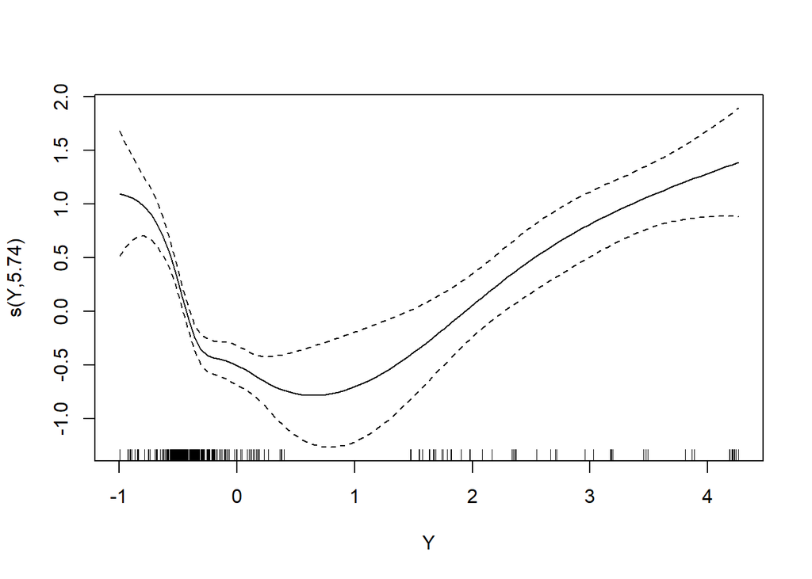

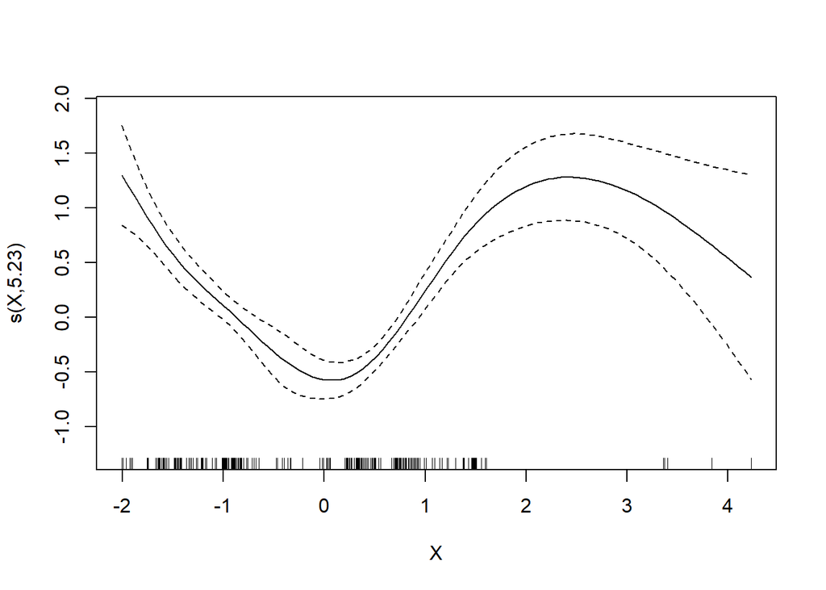

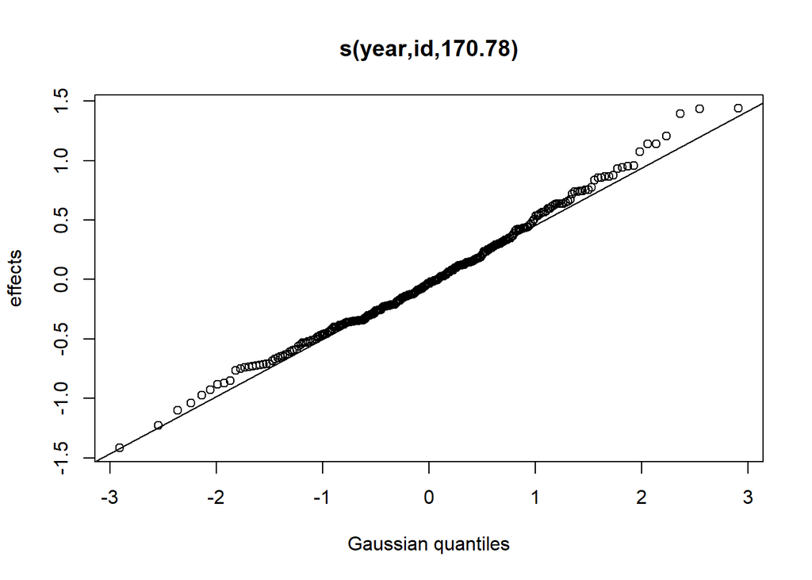

```r
plot(M2)
```

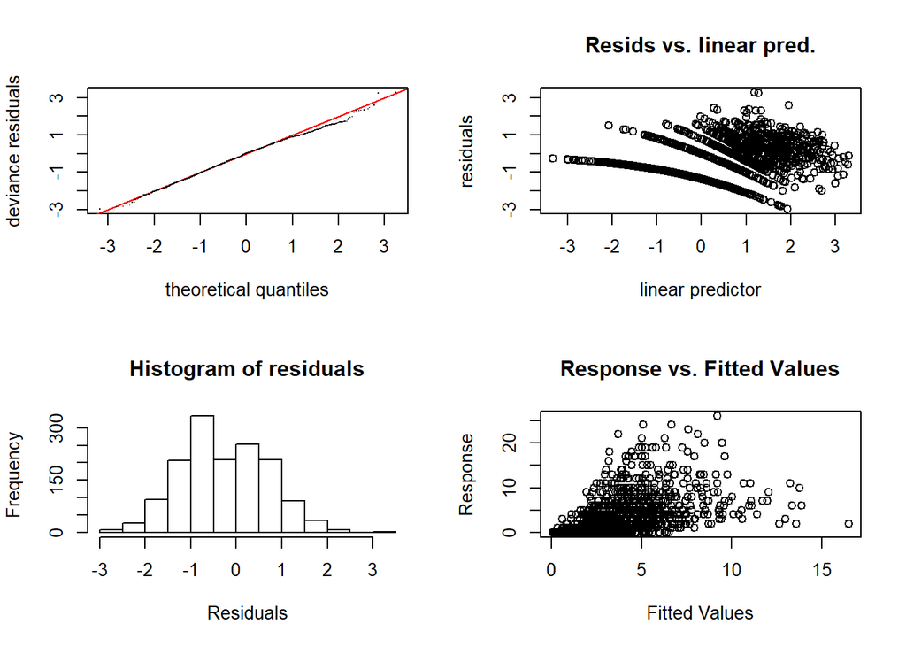

```
##
## Method: ML   Optimizer: outer newton
## full convergence after 7 iterations.
## Gradient range [-7.184539e-06,3.050307e-06]
## (score 2718.732 & scale 1).
## Hessian positive definite, eigenvalue range [0.9176327,53.87842].
## Model rank =  304 / 304
##
## Basis dimension (k) checking results. Low p-value (k-index<1) may
## indicate that k is too low, especially if edf is close to k'.
##
##                k'    edf k-index p-value
## s(Y)         9.00   5.74    0.69  <2e-16 ***
## s(X)         9.00   5.23    0.70  <2e-16 ***
## s(year,id) 277.00 170.78      NA      NA
## ---
## Signif. codes:  0 '***' 0.001 '**' 0.01 '*' 0.05 '.' 0.1 ' ' 1
```

```r
gam.check(M2)
```

Pitäisikö plotata vielä tarkemmin kukin muuttuja vs. residuaalit?

### 2.2.5 GAMM, NB, offset, (1 + vuosi|lauluryhmä)

**Offset argumenttina:** “Can be used to supply a model offset for use in fitting. Note that this offset will always be completely ignored when predicting, unlike an offset included in formula (this used to conform to the behaviour of lm and glm).” Eli jos argumenttina niin predicted arvot eivät huomioi offsettia. Kumpikohan olis fiksumpi?

**Random intercept ja random slope malli**

Random-muuttujan rakenne (lmer) cheat sheet [tässä](https://stats.stackexchange.com/questions/13166/rs-lmer-cheat-sheet).

V1 ~ (1+V3|V2) + V3

P1: A global intercept

P2: Random effect intercepts for V2 (i.e. for each level of V2, that level’s intercept’s deviation from the global intercept)

P3: A single global estimate for the effect (slope) of V3

P4: The effect of V3 within each level of V2 (more specifically, the degree to which the V3 effect within a given level deviates from the global effect of V3)

P5: The correlation between intercept deviations and V3 deviations across levels of V2

Eli intercept voi vaihdella kunkin lauluryhmän mukaan (lähtökohtaisesti joillain osapopulaatioilla on enemmän tai vähemmän reviirejä, joten yleistä mallia vääntäessä tämä vaihtelu pitää sallia ja ottaa huomioon). Random intercept malli kertoo kuinka paljon osapopulaatioiden välillä on “selittämätöntä” vaihtelua, eli vaihtelua siinä, miten paljon reviirien määrä johtuu jostain muuusta kuin fixed osan muuttujista.

Vuoden vaikutus reviirien määrään (slope) voi myös vaihdella osapopulaatioiden välillä. Jossain lasku on jyrkempi ja jossain loivempi. Slope ja intercept voivat korreloida jossain määrin keskenään eli esimerkiksi osapopulaatioilla, joilla on enemmän reviirejä myös vuosittainen lasku reviirien määrässä on jyrkempi. Tai toisinpäin.

Zuurin kommentit paketin valinnasta:  
What package should we use for a GAMM?

Function Package Uses Object names  
gamm4 gamm4 lme4 M1_mer M1_gam  
gamm mgcv nlme M1_lme M1_gam

To gamm4 or to mgcv?  
Gaussian: gamm4 or gamm  
Crossed random effects: use gamm4

Model heterogeneity: nlme but not in lme4. Use gamm  
Model correlation: Y_s = Covariate stuff_s + eps_s  
eps_s = rho * eps_s-1 + Pure Noise  
But….this is all in nlme….(gls and lme)..so only in gamm

Poisson/binomial:  
Use gamm4/lme4 ….you can compare AICs  
But also in gamm….but via PQL …therefore…cannot compare AICs

Adding correlation in Gaussian models:  
T1 <- gamm(Y ~ s(X), correlation = corAR1(form=~ Time))  
T1 <- gamm(Y ~ s(X), correlation = corSpher(form=~ Lat+Lon))

**Miten gamm malleja vertaillaan?** AIC ei kai ihan pätevä. gamm4 ja gamm funktioilla on ilmeisesti eroa. Katso Zuurin pingviiniesimerkit. Miten vapausasteet lasketaan gammeilla? smoothereissa on lineaarinen ja random osa? Eli yksi vai kaksi vapausastetta? Ratkaisee sen miten AIC lasketaan. Asiasta ei kai olla ihan yhtä mieltä. Zuur neuvoo tekemään analyysit Bayeslaisittain, jolloin tätä ongelmaa ei ole. Vai onko tämä ongelma vasta sitten kun vertailtavien mallien AIC arvot ovat hyvin lähekkäin. Jos niiden välillä on selvä ero -> AIC arvoihin voi luottaa??

mgvc.FAQ ([täällä](https://stat.ethz.ch/R-manual/R-devel/library/mgcv/html/mgcv-FAQ.html)):

*When using gamm or gamm4, the reported AIC is different for the gam object and the lme or lmer object. Why is this?* There are several reasons for this. The most important is that the models being used are actually different in the two representations. When treating the GAM as a mixed model, you are implicitly assuming that if you gathered a replicate dataset, the smooths in your model would look completely different to the smooths from the original model, except for having the same degree of smoothness. Technically you would expect the smooths to be drawn afresh from their distribution under the random effects model. When viewing the gam from the usual penalized regression perspective, you would expect smooths to look broadly similar under replication of the data. i.e. you are really using Bayesian model for the smooths, rather than a random effects model (it’s just that the frequentist random effects and Bayesian computations happen to coincide for computing the estimates). As a result of the different assumptions about the data generating process, AIC model comparisons can give rather different answers depending on the model adopted. Which you use should depend on which model you really think is appropriate. In addition the computations of the AICs are different. The mixed model AIC uses the marginal likelihood and the corresponding number of model parameters. The gam model uses the penalized likelihood and the effective degrees of freedom.

*How can I compare gamm models?* In the identity link normal errors case, then AIC and hypotheis testing based methods are fine. Otherwise it is best to work out a strategy based on the summary.gam Alternatively, simple random effects can be fitted with gam, which makes comparison straightforward. Package gamm4 is an alternative, which allows AIC type model selection for generalized models.

**Temporaalinen autokorrelaatio?** Peräkkäiset vuodet ovat reviirimäärältään samankaltaisempia kuin kauempana toisistaan olevat vuodet? corAR1 jutska.

**Negative binomial jakauman Theta?** gamm4-funktion negbin jakaumaan pitää määritellä theta. Miten se valitaan?

Zuurin kaksi tapaa arvioida theta:

1. Käytetään gamm4-funktiota ja kokeillaan erilaisia thetoja, katsotaan kuvaajasta, mikä antaa parhaimman AIC arvon

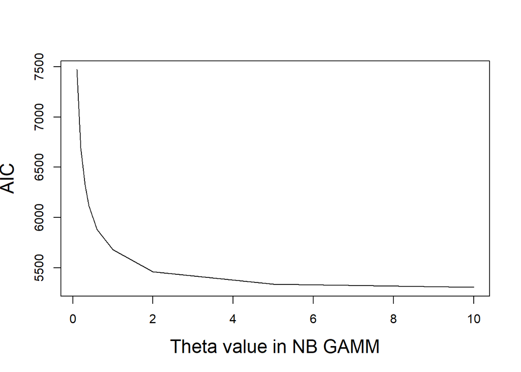

```r
AllThetas <- c(0.1, 0.2, 0.3, 0.4, 0.6, 1, 2, 5, 10)
AICs <- vector(length = 9)
i <- 1
for (MyTheta in AllThetas) {
       M1 <- gamm4(terri ~ SSS + agri5*year + s(Y) + s(X) + year*temp + year*prec + year*shanG + year*open + offset(log(area)),
                random =~ (1 + year| id),
                family = negbin(theta = MyTheta),
                data = dataS)
       AICs[i] <- AIC(M1$mer)  #<---
       i <- i + 1
}
# And plot the results
plot(x = AllThetas,
     y = AICs,
     xlab = "Theta value in NB GAMM",
     ylab = "AIC",
     cex.lab = 1.5,
     type = "l"
    )
```

Tästä ei tule tulokseksi mitään järkeävää. Tai AIC:t vaan laskee mitä isompi theta on. Onko se järkevä tulos?

2. Käytetään gam-funktiota, jolloin family=nb() arvioi itse sopivan thetan. Tätä varten random-tekijät pitää muuttaa smoothereiksi. En tiedä osasinko tehdä tämän oikein. Eli onko random =~ (1 + year| id) sama kuin s(year,id, bs = “re”) ?

```r
#thetan voisi arvioida sovittamalla mallin GAM:lla eli random tekijä smootheriksi. Mutta mikä malli tässä pitäisi olla? Monimutkaisin?

M6 <- gam(terri ~ SSS + agri5*year + s(Y) + s(X) + year*temp + year*prec + year*shanG + year*open + offset(log(area)) + s(year,id, bs =  "re"), family = nb(),data = dataS)
summary(M6)
```

```
##
## Family: Negative Binomial(5.443)
## Link function: log
##
## Formula:
## terri ~ SSS + agri5 * year + s(Y) + s(X) + year * temp + year *
##     prec + year * shanG + year * open + offset(log(area)) + s(year,
##     id, bs = "re")
##
## Parametric coefficients:
##             Estimate Std. Error z value Pr(>|z|)
## (Intercept)  0.86605    0.03672  23.586  < 2e-16 ***
## SSS          0.01873    0.02214   0.846 0.397506
## agri5        0.26111    0.05252   4.971 6.65e-07 ***
## year        -0.18158    0.05496  -3.304 0.000954 ***
## temp         0.07571    0.02873   2.636 0.008401 **
## prec        -0.03016    0.02859  -1.055 0.291517
## shanG        0.04920    0.03146   1.564 0.117865
## open        -0.04773    0.03660  -1.304 0.192197
## agri5:year   0.10505    0.05403   1.944 0.051843 .
## year:temp    0.08955    0.02784   3.217 0.001297 **
## year:prec   -0.04106    0.02483  -1.653 0.098231 .
## year:shanG   0.03964    0.03526   1.124 0.260937
## year:open    0.04844    0.04192   1.155 0.247898
## ---
## Signif. codes:  0 '***' 0.001 '**' 0.01 '*' 0.05 '.' 0.1 ' ' 1
##
## Approximate significance of smooth terms:
##                edf  Ref.df Chi.sq p-value
## s(Y)         7.635   8.151  178.4  <2e-16 ***
## s(X)         5.961   6.728  145.3  <2e-16 ***
## s(year,id) 170.493 276.000  606.9  <2e-16 ***
## ---
## Signif. codes:  0 '***' 0.001 '**' 0.01 '*' 0.05 '.' 0.1 ' ' 1
##
## R-sq.(adj) =  0.683   Deviance explained = 46.7%
## -REML = 2737.2  Scale est. = 1         n = 1474
```

```r
Theta <- M6$family$getTheta(TRUE)


# If you want then you can run M4 again with the optimal theta.
M4 <- gamm4(terri ~ SSS + agri5*year + s(Y) + s(X) + year*temp + year*prec + year*shanG + year*open + offset(log(area)),
            random = ~(1 + year|id),
            family = negbin(theta = Theta),
            data = dataS)

# M6 and M4 should now give similar results.
summary(M6)
```

```
##
## Family: Negative Binomial(5.443)
## Link function: log
##
## Formula:
## terri ~ SSS + agri5 * year + s(Y) + s(X) + year * temp + year *
##     prec + year * shanG + year * open + offset(log(area)) + s(year,
##     id, bs = "re")
##
## Parametric coefficients:
##             Estimate Std. Error z value Pr(>|z|)
## (Intercept)  0.86605    0.03672  23.586  < 2e-16 ***
## SSS          0.01873    0.02214   0.846 0.397506
## agri5        0.26111    0.05252   4.971 6.65e-07 ***
## year        -0.18158    0.05496  -3.304 0.000954 ***
## temp         0.07571    0.02873   2.636 0.008401 **
## prec        -0.03016    0.02859  -1.055 0.291517
## shanG        0.04920    0.03146   1.564 0.117865
## open        -0.04773    0.03660  -1.304 0.192197
## agri5:year   0.10505    0.05403   1.944 0.051843 .
## year:temp    0.08955    0.02784   3.217 0.001297 **
## year:prec   -0.04106    0.02483  -1.653 0.098231 .
## year:shanG   0.03964    0.03526   1.124 0.260937
## year:open    0.04844    0.04192   1.155 0.247898
## ---
## Signif. codes:  0 '***' 0.001 '**' 0.01 '*' 0.05 '.' 0.1 ' ' 1
##
## Approximate significance of smooth terms:
##                edf  Ref.df Chi.sq p-value
## s(Y)         7.635   8.151  178.4  <2e-16 ***
## s(X)         5.961   6.728  145.3  <2e-16 ***
## s(year,id) 170.493 276.000  606.9  <2e-16 ***
## ---
## Signif. codes:  0 '***' 0.001 '**' 0.01 '*' 0.05 '.' 0.1 ' ' 1
##
## R-sq.(adj) =  0.683   Deviance explained = 46.7%
## -REML = 2737.2  Scale est. = 1         n = 1474
```

```r
summary(M4$gam)
```

```
##
## Family: Negative Binomial(5.443)
## Link function: log
##
## Formula:
## terri ~ SSS + agri5 * year + s(Y) + s(X) + year * temp + year *
##     prec + year * shanG + year * open + offset(log(area))
##
## Parametric coefficients:
##              Estimate Std. Error z value Pr(>|z|)
## (Intercept)  0.908831   0.054831  16.575  < 2e-16 ***
## SSS          0.061617   0.029240   2.107   0.0351 *
## agri5        0.335933   0.065160   5.156 2.53e-07 ***
## year        -0.502783   0.047889 -10.499  < 2e-16 ***
## temp         0.064155   0.029060   2.208   0.0273 *
## prec        -0.029522   0.028982  -1.019   0.3084
## shanG        0.063355   0.034996   1.810   0.0702 .
## open         0.009698   0.041400   0.234   0.8148
## agri5:year   0.091833   0.047780   1.922   0.0546 .
## year:temp    0.068847   0.027543   2.500   0.0124 *
## year:prec   -0.048111   0.024894  -1.933   0.0533 .
## year:shanG   0.006078   0.034271   0.177   0.8592
## year:open    0.001441   0.039664   0.036   0.9710
## ---
## Signif. codes:  0 '***' 0.001 '**' 0.01 '*' 0.05 '.' 0.1 ' ' 1
##
## Approximate significance of smooth terms:
##        edf Ref.df Chi.sq  p-value
## s(Y) 5.199  5.199  91.54  < 2e-16 ***
## s(X) 5.020  5.020  51.81 5.91e-10 ***
## ---
## Signif. codes:  0 '***' 0.001 '**' 0.01 '*' 0.05 '.' 0.1 ' ' 1
##
## R-sq.(adj) =  0.485
## glmer.ML = 1159.4  Scale est. = 1         n = 1474
```

```r
summary(M4$mer)
```

```
## Generalized linear mixed model fit by maximum likelihood (Laplace
##   Approximation) [glmerMod]
##  Family: Negative Binomial(5.443)  ( log )
##
##      AIC      BIC   logLik deviance df.resid
##   5329.8   5441.0  -2643.9   5287.8     1453
##
## Scaled residuals:
##     Min      1Q  Median      3Q     Max
## -1.7300 -0.6236 -0.2654  0.4694  3.7679
##
## Random effects:
##  Groups Name        Variance Std.Dev. Corr
##  id     (Intercept)  0.4047  0.6361
##         year         0.1648  0.4060   0.58
##  Xr.0   s(X)         5.0141  2.2392
##  Xr     s(Y)        12.5888  3.5481
## Number of obs: 1474, groups:  id, 277; Xr.0, 8; Xr, 8
##
## Fixed effects:
##                 Estimate Std. Error z value Pr(>|z|)
## X.0(Intercept)  0.908831   0.058651  15.495  < 2e-16 ***
## X.0SSS          0.061617   0.029531   2.087   0.0369 *
## X.0agri5        0.335933   0.071472   4.700 2.60e-06 ***
## X.0year        -0.502783   0.065787  -7.643 2.13e-14 ***
## X.0temp         0.064155   0.028910   2.219   0.0265 *
## X.0prec        -0.029522   0.028367  -1.041   0.2980
## X.0shanG        0.063355   0.035379   1.791   0.0733 .
## X.0open         0.009698   0.041325   0.235   0.8145
## X.0agri5:year   0.091833   0.048456   1.895   0.0581 .
## X.0year:temp    0.068847   0.027746   2.481   0.0131 *
## X.0year:prec   -0.048111   0.024483  -1.965   0.0494 *
## X.0year:shanG   0.006078   0.034961   0.174   0.8620
## X.0year:open    0.001441   0.040161   0.036   0.9714
## X.0s(Y)Fx1     -1.192099   0.633261  -1.882   0.0598 .
## X.0s(X)Fx1     -0.285676   0.524305  -0.545   0.5858
## ---
## Signif. codes:  0 '***' 0.001 '**' 0.01 '*' 0.05 '.' 0.1 ' ' 1
```

```
##
## Correlation matrix not shown by default, as p = 15 > 12.
## Use print(x, correlation=TRUE)  or
##     vcov(x)        if you need it
```

```r
gam.vcomp(M6)
```

```
##
## Standard deviations and 0.95 confidence intervals:
##
##              std.dev     lower     upper
## s(Y)       4.2158513 1.9364557 9.1783160
## s(X)       1.2914670 0.6775807 2.4615327
## s(year,id) 0.6436163 0.5564441 0.7444449
##
## Rank: 3/3
```

Jos tässä kokeilussa oli väärin käyttää tuota monimutkaisinta mallia niin kokeillaan sitten myös yksinkertaisemmalla mallilla. Saanko saman thetan?

```r
M6 <- gam(terri ~ year + offset(log(area)) + s(year,id, bs =  "re"), family = nb(),data = dataS)
summary(M6)
```

```
##
## Family: Negative Binomial(2.44)
## Link function: log
##
## Formula:
## terri ~ year + offset(log(area)) + s(year, id, bs = "re")
##
## Parametric coefficients:
##             Estimate Std. Error z value Pr(>|z|)
## (Intercept)  1.02382    0.03287  31.152  < 2e-16 ***
## year         0.14411    0.04555   3.164  0.00156 **
## ---
## Signif. codes:  0 '***' 0.001 '**' 0.01 '*' 0.05 '.' 0.1 ' ' 1
##
## Approximate significance of smooth terms:
##              edf Ref.df Chi.sq p-value
## s(year,id) 144.5    276  373.8  <2e-16 ***
## ---
## Signif. codes:  0 '***' 0.001 '**' 0.01 '*' 0.05 '.' 0.1 ' ' 1
##
## R-sq.(adj) =  0.626   Deviance explained = 25.4%
## -REML = 2862.6  Scale est. = 1         n = 1474
```

```r
Theta2 <- M6$family$getTheta(TRUE)


# If you want then you can run M4 again with the optimal theta.
M4 <- gamm4(terri ~ year + offset(log(area)),
            random = ~(1 + year|id),
            family = negbin(theta = Theta2),
            data = dataS)

# M6 and M4 should now give similar results.
summary(M6)
```

```
##
## Family: Negative Binomial(2.44)
## Link function: log
##
## Formula:
## terri ~ year + offset(log(area)) + s(year, id, bs = "re")
##
## Parametric coefficients:
##             Estimate Std. Error z value Pr(>|z|)
## (Intercept)  1.02382    0.03287  31.152  < 2e-16 ***
## year         0.14411    0.04555   3.164  0.00156 **
## ---
## Signif. codes:  0 '***' 0.001 '**' 0.01 '*' 0.05 '.' 0.1 ' ' 1
##
## Approximate significance of smooth terms:
##              edf Ref.df Chi.sq p-value
## s(year,id) 144.5    276  373.8  <2e-16 ***
## ---
## Signif. codes:  0 '***' 0.001 '**' 0.01 '*' 0.05 '.' 0.1 ' ' 1
##
## R-sq.(adj) =  0.626   Deviance explained = 25.4%
## -REML = 2862.6  Scale est. = 1         n = 1474
```

```r
summary(M4$gam)
```

```
##
## Family: Negative Binomial(2.44)
## Link function: log
##
## Formula:
## terri ~ year + offset(log(area))
##
## Parametric coefficients:
##             Estimate Std. Error z value Pr(>|z|)
## (Intercept)  1.07912    0.06164  17.506   <2e-16 ***
## year        -0.40424    0.04243  -9.527   <2e-16 ***
## ---
## Signif. codes:  0 '***' 0.001 '**' 0.01 '*' 0.05 '.' 0.1 ' ' 1
##
##
## R-sq.(adj) =  0.466
## glmer.ML = 1038.1  Scale est. = 1         n = 1474
```

```r
summary(M4$mer)
```

```
## Generalized linear mixed model fit by maximum likelihood (Laplace
##   Approximation) [glmerMod]
##  Family: Negative Binomial(2.44)  ( log )
##
##      AIC      BIC   logLik deviance df.resid
##   5506.1   5537.9  -2747.1   5494.1     1468
##
## Scaled residuals:
##     Min      1Q  Median      3Q     Max
## -1.3601 -0.6129 -0.2039  0.4534  3.5188
##
## Random effects:
##  Groups Name        Variance Std.Dev. Corr
##  id     (Intercept) 0.7251   0.8515
##         year        0.1107   0.3326   0.79
## Number of obs: 1474, groups:  id, 277
##
## Fixed effects:
##              Estimate Std. Error z value Pr(>|z|)
## X(Intercept)  1.07912    0.06728  16.040  < 2e-16 ***
## Xyear        -0.40424    0.06727  -6.009 1.86e-09 ***
## ---
## Signif. codes:  0 '***' 0.001 '**' 0.01 '*' 0.05 '.' 0.1 ' ' 1
##
## Correlation of Fixed Effects:
##       X(Int)
## Xyear 0.134
```

```r
gam.vcomp(M6)
```

```
##
## Standard deviations and 0.95 confidence intervals:
##
##              std.dev     lower     upper
## s(year,id) 0.5413212 0.4576001 0.6403597
##
## Rank: 1/1
```

```r
Theta2
```

```
## [1] 2.439918
```

Nyt theta on 2.439918 eli eroaa edellisestä arviosta. Zuurin esimerkki ei selitä, mitä mallia thetan arvioinnissa pitäisi käyttää. Siinä käytetään mallia, johon on jo aiemmista kiemuroista päädytty, eikä esimerkissä tehdä mallin valintaa tämän jälkeen (etsitään vain sopiva theta ja sovitetaan negbin malli).

Nyt en oikein tiedä minkä thetan valitsisin. Toistaiseksi valitsen tuon ekan vaihtoehdon.

```r
#varsinaiset mallit, joissa theta arvioitu gam-mallin avulla

G1=gamm4(terri ~ year + offset(log(area)), random= ~(1 + year|id), family=negbin(theta=Theta), data=dataS)

G2=gamm4(terri ~ SSS + agri5*year + s(Y) + s(X) + year + offset(log(area)), random= ~(1 + year|id), family=negbin(theta=Theta), data=dataS)

G3=gamm4(terri ~ SSS + agri5*year + s(Y) + s(X)+ year*temp + year*prec + offset(log(area)), random= ~(1 + year|id), family=negbin(theta=Theta), data=dataS)

G4=gamm4(terri ~ SSS + agri5*year + s(Y) + s(X) + year*shan + year*open + offset(log(area)), random= ~(1 + year|id), family=negbin(theta=Theta), data=dataS)

G5=gamm4(terri ~ SSS + agri5*year + s(Y) + s(X) + year*temp + year*prec + year*shan + year*open + offset(log(area)), random= ~(1 + year|id), family=negbin(theta=Theta), data=dataS)
```

Malli G4 ilmoittaa “failure to converge in 10000 evaluations” mutta tämä ei kuitenkaan ole mikään error-viesti ja malli näyttää toimineen. Jännä juttu. Mulla on R:ssä asennettuna joku paketti, joka kertoo laskelmien edistymisestä. Teksti taitaa tulla sen takia. Selvitetään..

```r
AIC(G1$mer, G2$mer, G3$mer, G4$mer, G5$mer)
```

```
##        df      AIC
## G1$mer  6 5420.967
## G2$mer 13 5333.657
## G3$mer 17 5325.211
## G4$mer 17 5334.845
## G5$mer 21 5325.536
```

```r
anova(G1$mer, G2$mer, G3$mer, G4$mer, G5$mer)
```

```
## Data: NULL
## Models:
## G1$mer: NULL
## G2$mer: NULL
## G3$mer: NULL
## G4$mer: NULL
## G5$mer: NULL
##        Df    AIC    BIC  logLik deviance   Chisq Chi Df Pr(>Chisq)
## G1$mer  6 5421.0 5452.7 -2704.5   5409.0
## G2$mer 13 5333.7 5402.5 -2653.8   5307.7 101.310      7  < 2.2e-16 ***
## G3$mer 17 5325.2 5415.2 -2645.6   5291.2  16.446      4   0.002476 **
## G4$mer 17 5334.8 5424.9 -2650.4   5300.8   0.000      0   1.000000
## G5$mer 21 5325.5 5436.7 -2641.8   5283.5  17.309      4   0.001683 **
## ---
## Signif. codes:  0 '***' 0.001 '**' 0.01 '*' 0.05 '.' 0.1 ' ' 1
```

G3 ja G5 näyttävät saavan pienimmät AIC arvot. Ero näiden välillä on hyvin pieni. Mutta joissain esimerkeissä vertaillaan BIC arvoja, näissä mitattuna G2 olisi paras.

Entäs kun ero on noin mitättömän pieni? Valitaanko yksinkertaisempi malli? G3?

```r
summary(G3$gam)
```

```
##
## Family: Negative Binomial(5.443)
## Link function: log
##
## Formula:
## terri ~ SSS + agri5 * year + s(Y) + s(X) + year * temp + year *
##     prec + offset(log(area))
##
## Parametric coefficients:
##             Estimate Std. Error z value Pr(>|z|)
## (Intercept)  0.91016    0.05513  16.509  < 2e-16 ***
## SSS          0.06239    0.02951   2.115   0.0345 *
## agri5        0.34118    0.06590   5.177 2.26e-07 ***
## year        -0.50586    0.04779 -10.585  < 2e-16 ***
## temp         0.06558    0.02893   2.267   0.0234 *
## prec        -0.02893    0.02892  -1.000   0.3171
## agri5:year   0.09413    0.04818   1.954   0.0507 .
## year:temp    0.06819    0.02749   2.481   0.0131 *
## year:prec   -0.04704    0.02483  -1.894   0.0582 .
## ---
## Signif. codes:  0 '***' 0.001 '**' 0.01 '*' 0.05 '.' 0.1 ' ' 1
##
## Approximate significance of smooth terms:
##        edf Ref.df Chi.sq  p-value
## s(Y) 5.360  5.360  90.45  < 2e-16 ***
## s(X) 5.037  5.037  51.88 5.89e-10 ***
## ---
## Signif. codes:  0 '***' 0.001 '**' 0.01 '*' 0.05 '.' 0.1 ' ' 1
##
## R-sq.(adj) =  0.487
## glmer.ML = 1152.2  Scale est. = 1         n = 1474
```

```r
summary(G3$mer)
```

```
## Generalized linear mixed model fit by maximum likelihood (Laplace
##   Approximation) [glmerMod]
##  Family: Negative Binomial(5.443)  ( log )
##
##      AIC      BIC   logLik deviance df.resid
##   5325.2   5415.2  -2645.6   5291.2     1457
##
## Scaled residuals:
##     Min      1Q  Median      3Q     Max
## -1.7317 -0.6237 -0.2586  0.4527  3.6565
##
## Random effects:
##  Groups Name        Variance Std.Dev. Corr
##  id     (Intercept)  0.4184  0.6468
##         year         0.1696  0.4118   0.58
##  Xr.0   s(X)         5.1943  2.2791
##  Xr     s(Y)        14.7078  3.8351
## Number of obs: 1474, groups:  id, 277; Xr.0, 8; Xr, 8
##
## Fixed effects:
##                Estimate Std. Error z value Pr(>|z|)
## X.0(Intercept)  0.91016    0.05913  15.391  < 2e-16 ***
## X.0SSS          0.06239    0.02983   2.092   0.0365 *
## X.0agri5        0.34118    0.07267   4.695 2.67e-06 ***
## X.0year        -0.50586    0.06572  -7.698 1.39e-14 ***
## X.0temp         0.06558    0.02879   2.278   0.0227 *
## X.0prec        -0.02893    0.02832  -1.022   0.3070
## X.0agri5:year   0.09413    0.04881   1.928   0.0538 .
## X.0year:temp    0.06819    0.02765   2.466   0.0137 *
## X.0year:prec   -0.04704    0.02443  -1.926   0.0541 .
## X.0s(Y)Fx1     -1.19565    0.64934  -1.841   0.0656 .
## X.0s(X)Fx1     -0.28388    0.53330  -0.532   0.5945
## ---
## Signif. codes:  0 '***' 0.001 '**' 0.01 '*' 0.05 '.' 0.1 ' ' 1
##
## Correlation of Fixed Effects:
##             X.0(I) X.0SSS X.0gr5 X.0yer X.0tmp X.0prc X.0g5: X.0yr:t
## X.0SSS       0.025
## X.0agri5    -0.128  0.186
## X.0year      0.197 -0.143 -0.187
## X.0temp     -0.057 -0.004 -0.020  0.123
## X.0prec     -0.018 -0.014 -0.056  0.036  0.290
## X.0agri5:yr -0.219 -0.053  0.170 -0.065 -0.004  0.059
## X.0year:tmp -0.031 -0.014  0.070  0.084 -0.096 -0.412  0.022
## X.0year:prc  0.070 -0.012  0.013  0.036 -0.375  0.157  0.002  0.297
## X.0s(Y)Fx1   0.066 -0.013 -0.254  0.115  0.018  0.018 -0.074 -0.008
## X.0s(X)Fx1   0.023  0.072  0.111 -0.105 -0.045 -0.034 -0.054  0.014
##             X.0yr:p X.0(Y)
## X.0SSS
## X.0agri5
## X.0year
## X.0temp
## X.0prec
## X.0agri5:yr
## X.0year:tmp
## X.0year:prc
## X.0s(Y)Fx1   0.011
## X.0s(X)Fx1   0.024  -0.056
```

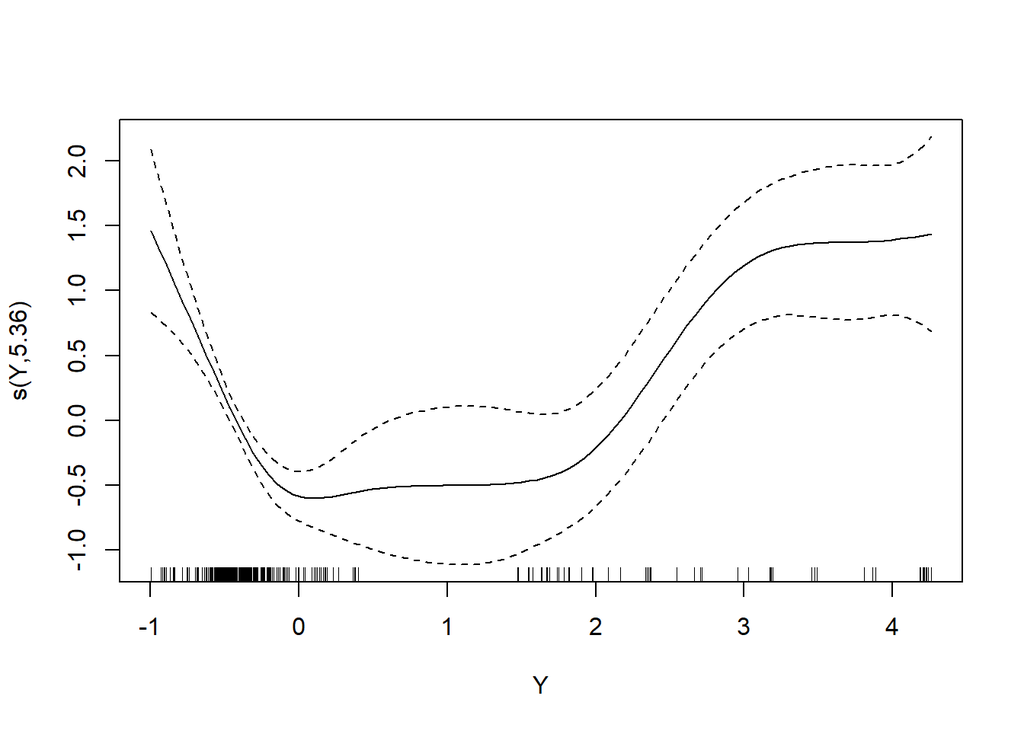

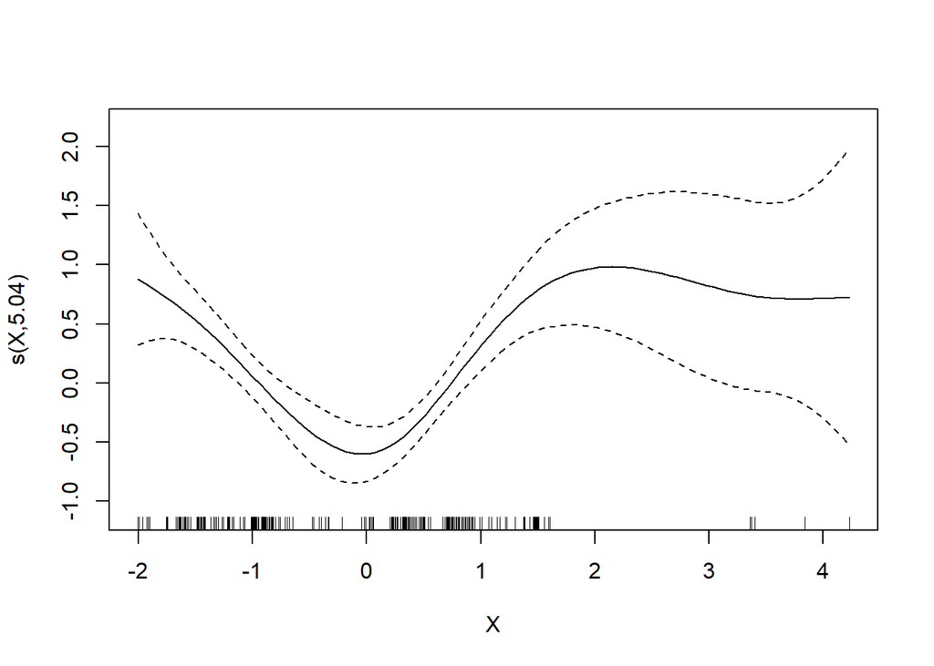

```r
plot(G3$gam)
```

Hmm.. Mitähän näistä nyt sanoisi?

**Mallin validointia seuraavaksi.**  
Ilmeisesti NB voi myös olla overdispersed.

```r
#Check dispersion parameter
p <- sum(G3$gam$edf) + 1 + 1 #theta and sigma id,  MITÄ TÄHÄN PITÄISI KIRJATA, tuleeko crossed random effectseistä vielä yksi degree of freedom lisää? vielä yksi +1?
N <- nrow(dataS)
E4 <- resid(G3$mer, type = "pearson")
Overdisp <- sum(E4^2) / (N - p)
Overdisp
```

```
## [1] 0.621609
```

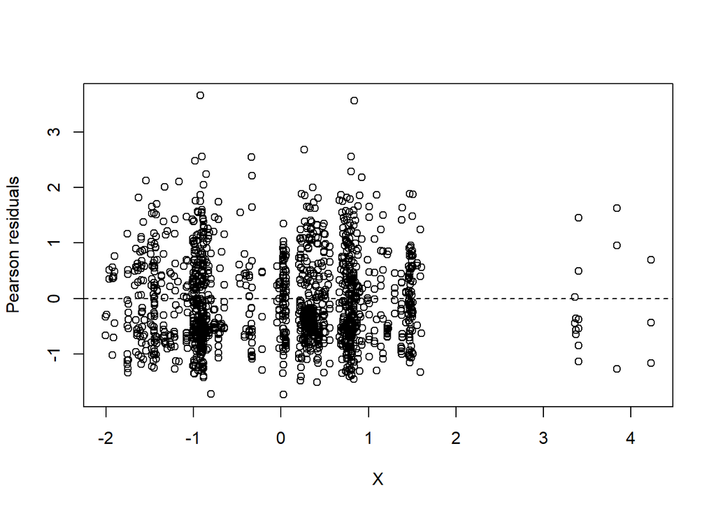

```r
#Plot residuals vs ...
plot(x = dataS$X,
     y = E4,
     xlab = "X",
     ylab = "Pearson residuals")
abline(h = 0, lty = 2)
```

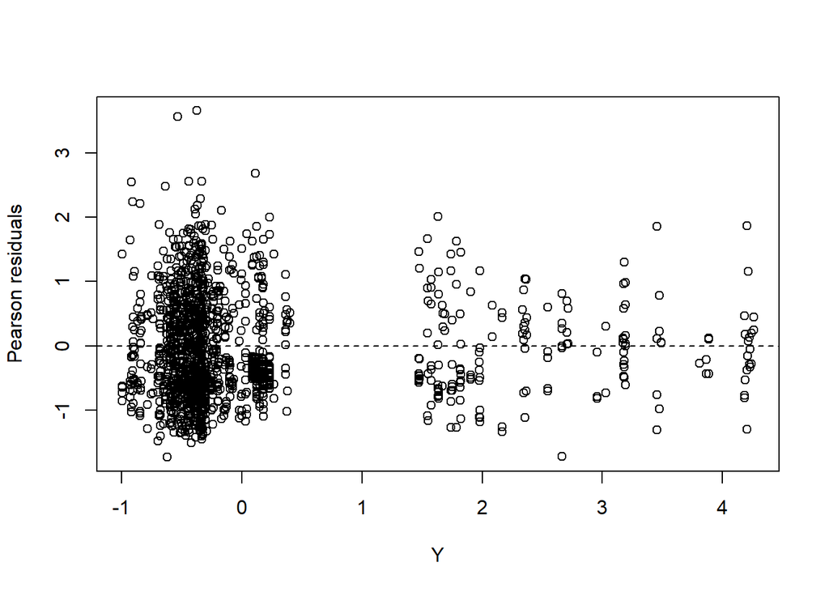

```r
#Plot residuals vs ...
plot(x = dataS$Y,
     y = E4,
     xlab = "Y",
     ylab = "Pearson residuals")
abline(h = 0, lty = 2)
```

```r
#Is there a non-linear pattern in here?
T1 <- gam(E4 ~ s(Y), data = dataS)
summary(T1)
```

```
##
## Family: gaussian
## Link function: identity
##
## Formula:
## E4 ~ s(Y)
##
## Parametric coefficients:
##             Estimate Std. Error t value Pr(>|t|)
## (Intercept) -0.05889    0.02034  -2.895  0.00385 **
## ---
## Signif. codes:  0 '***' 0.001 '**' 0.01 '*' 0.05 '.' 0.1 ' ' 1
##
## Approximate significance of smooth terms:
##      edf Ref.df     F p-value
## s(Y)   1      1 0.012   0.914
##
## R-sq.(adj) =  -0.000671   Deviance explained = 0.000793%
## GCV = 0.61077  Scale est. = 0.60994   n = 1474
```

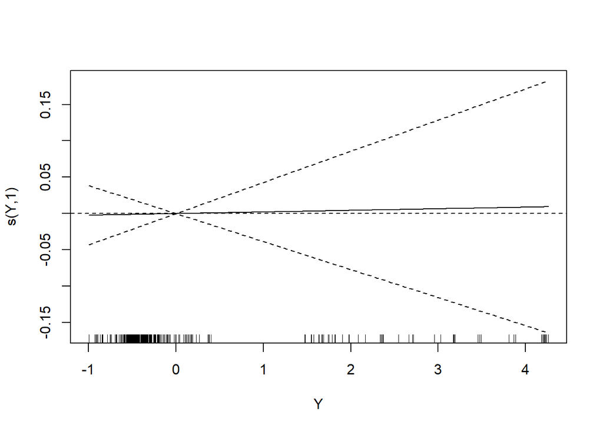

```r
plot(T1)
abline(h = 0, lty = 2)
```

Tää validointi on Zuurin esimerkistä GAMM NB esimerkistä. En vielä osaa sen kummemmin tulkita näitä. Enkä tiedä mitä kaikkea pitäisi plotata.

Samat mallit voisi tehdä vielä niin, että SSS on eroteltu Abuild + Astream + Aroad + Ariver. Kokeilen tätä sitten myöhemmin kun päädyn johonkin ratkaisuun mallin rakenteesta ja funktiosta.

#### 2.2.6 gamm-funktio

Samat mallit voisi ajaa myös gamm-funktiolla mutta miten tehdään mallin vertailu jos AIC ei ole käytettävissä? Paitsi, että Zuurin kirjassa AIC vertailua tehdään kyllä ihan mennen tullen.

```r
G1=gamm(terri ~ year, offset=log(area), random= list(id=~1+year), family=nbinom2, data=dataS)
```

```
##
##  Maximum number of PQL iterations:  20
```

[output not shown]

[output not shown]

[output not shown]

[output not shown]

[output not shown]

[output not shown]

[output not shown]

[output not shown]

[output not shown]

```r
G2=gamm(terri ~ SSS + agri5*year + s(Y,bs="cr") + s(X,bs="cr") + year , offset=log(area), random= list(id=~1+year), family=nbinom2, data=dataS)
```

```
##
##  Maximum number of PQL iterations:  20
```

[output not shown]

[output not shown]

[output not shown]

[output not shown]

[output not shown]

[output not shown]

[output not shown]

[output not shown]

```r
G3=gamm(terri ~ SSS + agri5*year + s(Y,bs="cr") + s(X,bs="cr")+ year*temp + year*prec , offset=log(area), random= list(id=~1+year), family=nbinom2, data=dataS)
```

```
##
##  Maximum number of PQL iterations:  20
```

[output not shown]

[output not shown]

[output not shown]

[output not shown]

[output not shown]

[output not shown]

[output not shown]

[output not shown]

```r
G4=gamm(terri ~ SSS + agri5*year + s(Y,bs="cr") + s(X,bs="cr") + year*shan + year*open, offset=log(area), random= list(id=~1+year), family=nbinom2, data=dataS)
```

```
##
##  Maximum number of PQL iterations:  20
```

[output not shown]

[output not shown]

[output not shown]

[output not shown]

[output not shown]

[output not shown]

[output not shown]

```r
G5=gamm(terri ~ SSS + agri5*year + s(Y,bs="cr") + s(X,bs="cr") + year*temp + year*prec + year*shan + year*open, offset=log(area), random= list(id=~1+year), family=nbinom2, data=dataS)
```

```
##
##  Maximum number of PQL iterations:  20
```

[output not shown]

[output not shown]

[output not shown]

[output not shown]

[output not shown]

[output not shown]

[output not shown]

```r
AIC(G1$lme, G2$lme, G3$lme, G4$lme, G5$lme)
```

```
##        df      AIC
## G1$lme  6 4841.897
## G2$lme 13 4822.625
## G3$lme 17 4840.281
## G4$lme 17 4803.988
## G5$lme 21 4821.044
```

Hmm.. Tämän mukaan malli G4 on paras. Selvällä erolla.

Jatka tästä..